# Dietze_CADS4_Notebook_TeilB

## Block B (Krankenversicherung) [75 Punkte]

Vanessa Dietze, 08.10.2024

Sie sind im Aktuariat der Krankenversicherung „AKK“, einem der innovativsten Unternehmen am Markt, tätig. Gemeinsam mit ihrem Team versuchen Sie immer wieder neue Services für Ihre Kunden zu entwickeln. Im Zuge der Gesetzesänderung zur Digitalisierung im Gesundheitswesen, siehe https://www.bundesgesundheitsministerium.de/presse/pressemitteilungen/bundeskabinett-be-schliesst-digitalgesetze-fuer-bessere-versorgung-und-forschung-im-gesund-heitswesen erwarten auch Sie in Ihrem Unternehmen Veränderungen. Konkret dürfen künftig Versicherungsnehmer:innen kontaktiert werden, wenn ein erhöhtes Risiko für gewisse Krankheiten vermutet wird. Sie möchten diese nun klargestellte Möglichkeit nutzen und ihre Kunden darüber informieren und im Rahmen eines Case Managements versuchen den Ausbruch der Krankheit zu verhindern oder zumindest zu verzögern. Hierfür müssen Sie zunächst ein gutes Modell zur Erkennung potentieller, künftiger Krankheiten entwickeln. Die Idee ist, anhand verschiedener Merkmale wie Alter, Geschlecht, oder BMI, sowie der medizinischen Historie (bisherige Behandlungen) eine Vorhersage für künftige Krankheiten abzuleiten. Als Datengrundlage dient der Datensatz Diagnosedaten.csv. Dieser umfasst, neben Informationen zur versicherten Person eine Historie vergangener, durch die AKK erfasste Diagnosen.

```python
# Importieren aller relevanten Pakete und Setzen globaler Variablen
import pandas as pd
import warnings
import matplotlib.pyplot as plt
import seaborn as sns
import numpy as np
import tensorflow as tf
import random
from tensorflow.keras.preprocessing.text import Tokenizer
from tensorflow.keras.preprocessing.sequence import pad_sequences
from sklearn.model_selection import train_test_split
from tensorflow.keras.models import Model
from tensorflow.keras.layers import Input, Embedding, LSTM, Dense, Concatenate, Dropout, Flatten
from tensorflow.keras.utils import to_categorical
from sklearn.metrics import roc_auc_score
from sklearn.utils.class_weight import compute_class_weight
from imblearn.over_sampling import RandomOverSampler
from keras.callbacks import EarlyStopping
from sklearn.ensemble import IsolationForest
from sklearn.utils import class_weight
warnings.filterwarnings('ignore')
set_seed = 10
np.random.seed(set_seed)
random.seed(set_seed)
tf.random.set_seed(set_seed)
```

```
2025-05-25 17:47:17.604321: I tensorflow/core/platform/cpu_feature_guard.cc:210] This TensorFlow binary is optimized to use available CPU instructions in performance-critical operations.
To enable the following instructions: AVX2 FMA, in other operations, rebuild TensorFlow with the appropriate compiler flags.
```

```python
# Definitionen und Funktionen

# Einfache Plots
def plot_data(plot_type, title, xlabel, ylabel, col, dataframe, colourscheme, figsize, bins=None, kde=None, rotation=None):
    plt.figure(figsize=figsize)
    if plot_type == 'hist':
        sns.histplot(dataframe[col], bins=bins, kde=kde)
    elif plot_type == 'count':
        sns.countplot(x=col, data=dataframe, palette=colourscheme)
    elif plot_type == 'bar':
        sns.barplot(x=col, y=dataframe, palette=colourscheme)
        plt.xticks(rotation=rotation)
    plt.title(title)
    plt.xlabel(xlabel)
    plt.ylabel(ylabel)
    plt.show()

# Funktion zum Berechnen der Wahrscheinlichkeiten aus Historiendaten
def calculate_probability_from_history(group_data, variable):
    ka_count = group_data['Historie'].str.contains(variable).sum()
    total_count = len(group_data)
    return ka_count / total_count
```

### Aufgabe 1. [Datenanalyse] [10 Punkte]

#### (a) Explorative Datenanalyse und Verständnis

Lesen Sie die Datei Diagnosedaten.csv ein. Die Spalten “D1”, “D2”, ... , “D10” beschreiben für eine Historie von 10 Jahren die bisherigen Behandlungen - diese werden in Spalte “Historie” aggregiert. Bei den Werten handelt es sich um die ICD10-Kodierungen, welche jeweils für eine gewisse Krankheit stehen. Sind in einem Jahr mehrere Krankheiten erfasst worden, wird nur die schwerwiegendste gespeichert. Sind in einem Jahr keine Krankheiten erfasst worden, wird “ka” für “keine Angabe” gespeichert. Die gespeicherten Krankheiten sind auf grober Diagnoseebene erfasst (keine 4. und 5. Stellen oder Zusatzinformationen). Wird in einem Jahr beispielsweise „F10“ erfasst, war eine Behandlung aufgrund „Psychische und Verhaltensstörungen durch Alkohol“ in diesem Jahr am schwerwiegendsten.

```python
# Datensatz laden
diagnosesData_path = '/Users/vanessadietze/Documents/Dokumente/Vanessa/DAV Ausbildung/ADS/ADS4/Abgabe/PRF3116_Aufgaben_D/Diagnosedaten.csv'
dfdiagnoses_raw = pd.read_csv(diagnosesData_path)

# Anzeigen der ersten Zeilen der Diagnose Daten
dfdiagnoses_raw.head()
```

|  | ID | Geschlecht | BMI | Raucherstatus | Alter | D1 | D2 | D3 | D4 | D5 | D6 | D7 | D8 | D9 | D10 | Historie |
| --- | --- | --- | --- | --- | --- | --- | --- | --- | --- | --- | --- | --- | --- | --- | --- | --- |
| 0 | 1 | Frau | ok | Raucher | 19 | J20 | G43 | F10 | R51 | C18 | T81 | F10 | C18 | F43 | F10 | j20 g43 f10 r51 c18 t81 f10 c18 f43 f10 |
| 1 | 2 | Mann | schlecht | Nichtraucher | 18 | R07 | kA | kA | I95 | kA | F10 | F19 | F10 | C18 | kA | r07 ka ka i95 ka f10 f19 f10 c18 ka |
| 2 | 3 | Mann | schlecht | Nichtraucher | 28 | L50 | kA | N20 | kA | kA | kA | J20 | kA | S06 | kA | l50 ka n20 ka ka ka j20 ka s06 ka |
| 3 | 4 | Mann | ok | Nichtraucher | 33 | K92 | kA | S06 | kA | F12 | F19 | F10 | kA | C18 | F10 | k92 ka s06 ka f12 f19 f10 ka c18 f10 |
| 4 | 6 | Frau | ok | Nichtraucher | 31 | F10 | kA | kA | O80 | F13 | G43 | G43 | N13 | kA | O60 | f10 ka ka o80 f13 g43 g43 n13 ka o60 |

Führen Sie eine explorative Datenanalyse durch.

Kommentar: Um Datenqualität sicherzustellen, bspw. keine Unterschiede in der Groß- und Kleinschreibung, werden alle Buchstaben in Großbuchstaben umgewandelt. Aus diesen großgeschriebenen Diagnosen wird dann wieder die Historie gebildet. Zudem wird geprüft, ob es keine Null Werte in den einzelnen Spalten gibt.

```python
# Großschreibung aller Buchstaben
for col in ['D1', 'D2', 'D3', 'D4', 'D5', 'D6', 'D7', 'D8', 'D9', 'D10']:
    dfdiagnoses_raw[col] = dfdiagnoses_raw[col].str.upper()

# Zusammenstellen der Historie aus den Spalten
dfdiagnoses_raw['Historie'] = dfdiagnoses_raw[['D1', 'D2', 'D3', 'D4', 'D5', 'D6', 'D7', 'D8', 'D9', 'D10']].apply(lambda x: ' '.join(x), axis=1)

# Prüfen der Spalten auf "null" Werte
print(f"Anzahl leerer Werte in den Daten: \n{dfdiagnoses_raw.isnull().sum()}")
```

```
Anzahl leerer Werte in den Daten:
ID               0
Geschlecht       0
BMI              0
Raucherstatus    0
Alter            0
D1               0
D2               0
D3               0
D4               0
D5               0
D6               0
D7               0
D8               0
D9               0
D10              0
Historie         0
dtype: int64
```

```python
# generelle Informationen über die Diagnosedaten
print(f"Generelle Informationen: \n{dfdiagnoses_raw.info()}")

# Summary Statistiken der Diagnosedaten
print(f"\nSummary Statistiken des Datensets: \n{dfdiagnoses_raw.describe(include='all')}")
```

```
<class 'pandas.core.frame.DataFrame'>
RangeIndex: 9995 entries, 0 to 9994
Data columns (total 16 columns):
 #   Column         Non-Null Count  Dtype
---  ------         --------------  -----
 0   ID             9995 non-null   int64
 1   Geschlecht     9995 non-null   object
 2   BMI            9995 non-null   object
 3   Raucherstatus  9995 non-null   object
 4   Alter          9995 non-null   int64
 5   D1             9995 non-null   object
 6   D2             9995 non-null   object
 7   D3             9995 non-null   object
 8   D4             9995 non-null   object
 9   D5             9995 non-null   object
 10  D6             9995 non-null   object
 11  D7             9995 non-null   object
 12  D8             9995 non-null   object
 13  D9             9995 non-null   object
 14  D10            9995 non-null   object
 15  Historie       9995 non-null   object
dtypes: int64(2), object(14)
memory usage: 1.2+ MB
Generelle Informationen:
None

Summary Statistiken des Datensets:
                  ID Geschlecht   BMI Raucherstatus        Alter    D1    D2  \
count    9995.000000       9995  9995          9995  9995.000000  9995  9995
unique           NaN          2     3             2          NaN   204   203
top              NaN       Mann    ok  Nichtraucher          NaN    KA    KA
freq             NaN       5070  4463          7929          NaN  2674  2735
mean     5002.993397        NaN   NaN           NaN    39.002501   NaN   NaN
std      2885.463727        NaN   NaN           NaN    14.078999   NaN   NaN
min         1.000000        NaN   NaN           NaN    18.000000   NaN   NaN
25%      2504.500000        NaN   NaN           NaN    26.000000   NaN   NaN
50%      5003.000000        NaN   NaN           NaN    39.000000   NaN   NaN
75%      7501.500000        NaN   NaN           NaN    51.000000   NaN   NaN
max     10000.000000        NaN   NaN           NaN    64.000000   NaN   NaN

```

[output cut: 10 more lines]

```
75%      NaN   NaN   NaN   NaN   NaN   NaN   NaN   NaN
max      NaN   NaN   NaN   NaN   NaN   NaN   NaN   NaN

                              Historie
count                             9995
unique                            9993
top     KA KA KA KA KA KA C18 KA KA KA
freq                                 2
mean                               NaN
std                                NaN
min                                NaN
25%                                NaN
50%                                NaN
75%                                NaN
max                                NaN
```

Kommentar: Man erkennt, dass es keine "null" Werte gibt und jede Spalte 9995 Einträge hat. Auch die Merkmale Geschlecht, BMI und Raucherstatus haben jeweils 2, 3 und 2 Ausprägungen, somit ist auch hier die Qualität der Daten bezüglich Rechtschreibung und Groß- und Kleinschreibung sicher gestellt. Geschlecht hat hier die Ausprägungen "Mann" und "Frau", BMI die Ausprägungen "ok", "schlecht", "extrem" und Raucherstatus kann "Raucher" oder "Nichtraucher" annehmen. Zudem sind diese Merkmale alle kategorielle Variablen. Die Spalten D1-D10 und Historie sind auch kategorielle Variablen. ID und Alter sind numerisch. Die Altersrange geht von 18 bis 64.

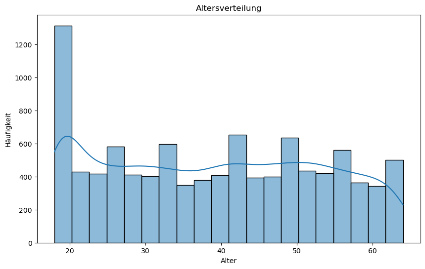

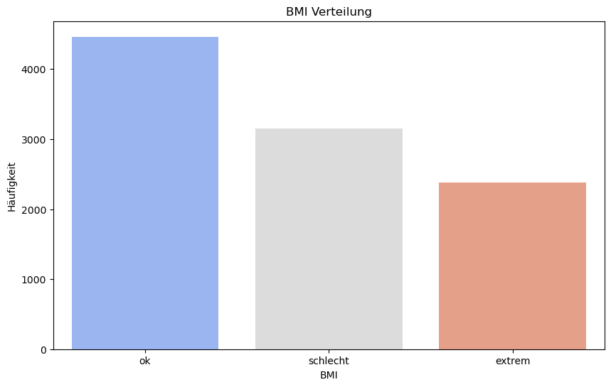

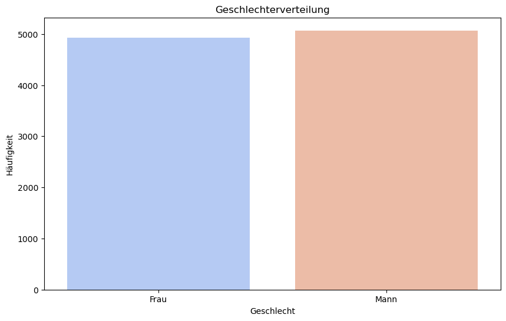

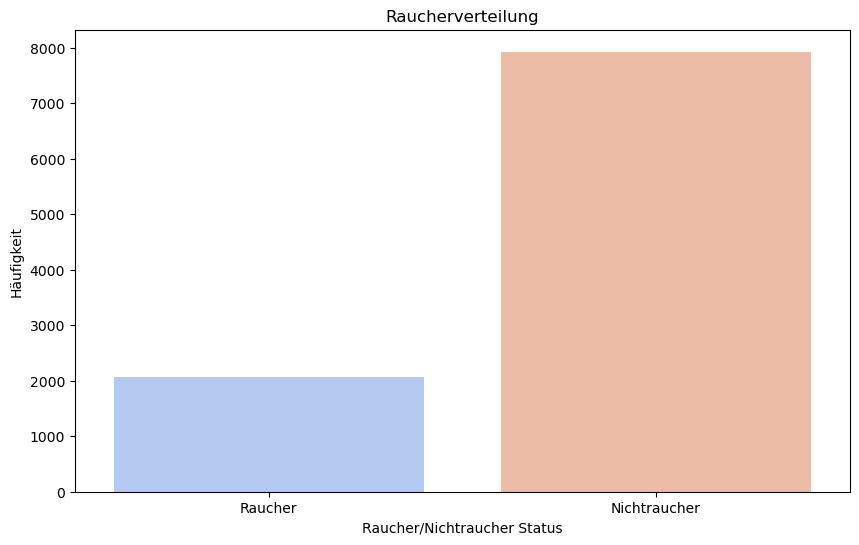

```python
# Verteilungen der einzelnen Merkmale
# Altersverteilung
plot_data('hist', 'Altersverteilung', 'Alter', 'Häufigkeit', 'Alter', dfdiagnoses_raw, 'coolwarm', (10,6), bins=20, kde=True)

# BMI Verteilung
plot_data('count', 'BMI Verteilung', 'BMI', 'Häufigkeit', 'BMI', dfdiagnoses_raw, 'coolwarm', (10,6))

# Geschlechterverteilung
plot_data('count', 'Geschlechterverteilung', 'Geschlecht', 'Häufigkeit', 'Geschlecht', dfdiagnoses_raw, 'coolwarm', (10,6))

# Raucherverteilung
plot_data('count', 'Raucherverteilung', 'Raucher/Nichtraucher Status', 'Häufigkeit', 'Raucherstatus', dfdiagnoses_raw, 'coolwarm', (10,6))
```

Kommentar: Die Altersverteilung hat große Häufigkeiten am Anfang der Altersstufen von 18-20 Jahren. Danach gibt es einige etwas höhere Ausschläge aber generell liegen die Altersstufen auf gleicher Ebene der Häufigkeiten (bei etwa 400 mit Ausschlägen bis ca. 650).  
Die häufigsten Vorkommnisse bei BMI ist ok (ca. 4500) gefolgt von schlecht (ca. 3000) und extrem (ca. 2500).  
Frauen und Männer sind in etwa gleichverteilt, wobei die Männer leicht überwiegen.  
In dem Datensatz gibt es deutlich mehr Nichtraucher als Raucher (ca. 8000 zu 2000).

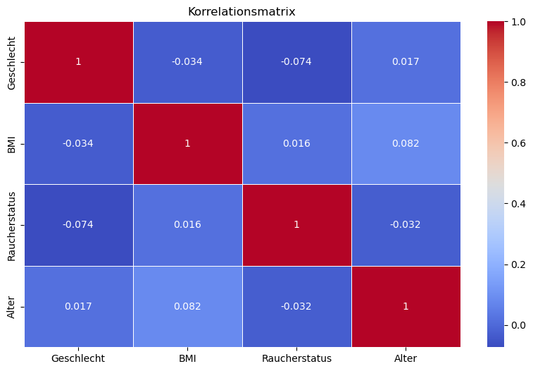

```python
# Geschlecht und Raucherstatus sind kategoriell, zum Vergleichen encoden
dfdiagnoses_encoded = dfdiagnoses_raw.copy(deep=True)
dfdiagnoses_encoded['Geschlecht'] = dfdiagnoses_encoded['Geschlecht'].map({'Mann': 0, 'Frau': 1})
dfdiagnoses_encoded['Raucherstatus'] = dfdiagnoses_encoded['Raucherstatus'].map({'Nichtraucher': 0, 'Raucher': 1})
dfdiagnoses_encoded['BMI'] = dfdiagnoses_encoded['BMI'].map({'ok': 0, 'schlecht': 1, 'extrem': 2})

# Numerische Spalten des Datensatzes, ID nicht relevant für Korrelation
dfdiagnoses_encoded_numeric = dfdiagnoses_encoded.select_dtypes(include=[float, int])
dfdiagnoses_encoded_numeric = dfdiagnoses_encoded_numeric.drop(columns=['ID'])

# Korrelationsmatrix berechnen
correlation_matrix = dfdiagnoses_encoded_numeric.corr()
plt.figure(figsize=(10, 6))
sns.heatmap(correlation_matrix, annot=True, cmap='coolwarm', linewidths=0.5)
plt.title('Korrelationsmatrix')
plt.show()
```

Kommentar: Man erkennt deutlich, dass die Merkmale kaum miteinander korrelieren. Die höchste positive Korrelation liegt bei 0.082 (Alter und BMI) und die negativste Korrelation liegt bei -0.074 (Raucherstatus und Geschlecht). Diese Korrelationen befinden sich sehr nahe an 0, sodass man hier von so gut wie keiner Korrelation ausgehen kann.

Visualisieren Sie die zehn häufigsten Krankheiten im ersten Diagnosejahr.

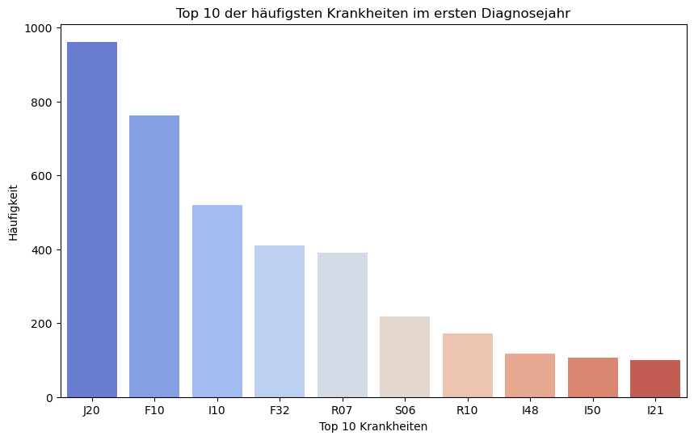

```python
# Visualisieren der zehn häufigsten Krankheiten im ersten Diagnosejahr (D1)
# "KA" ausschließen, da es keine Krankheit darstellt
top_10_diseases = dfdiagnoses_encoded[dfdiagnoses_encoded['D1'] != 'KA']['D1'].value_counts().nlargest(10)
plot_data('bar', 'Top 10 der häufigsten Krankheiten im ersten Diagnosejahr', 'Top 10 Krankheiten', 'Häufigkeit', top_10_diseases.index,
          top_10_diseases.values, 'coolwarm', (10,6), 45)
```

Kommentar: Oben sieht man die häufigsten 10 Krankheiten im ersten Diagnosejahr. Am häufigsten tritt hier die Krankheit J20, Akute Bronchitis, auf. Dicht folgend sind F10 (Psychische und Verhaltensstörungen durch Alkohol), I10 (Bluthochdruck) und F32 (Depression). Zudem gehören in absteigender Reihenfolge die folgenden Krankheiten unter die Top10:  
R07 Hals- und Brustschmerzen  
S06 Intrakranielle Verletzung  
R10 Bauch- und Beckenschmerzen  
I48 Vorhofflimmern und Vorhofflattern  
I50 Herzinsuffizienz  
I21 Akuter Myokardinfarkt

Was sind Auffälligkeiten von Rauchern im Vergleich zu Nichtrauchern?

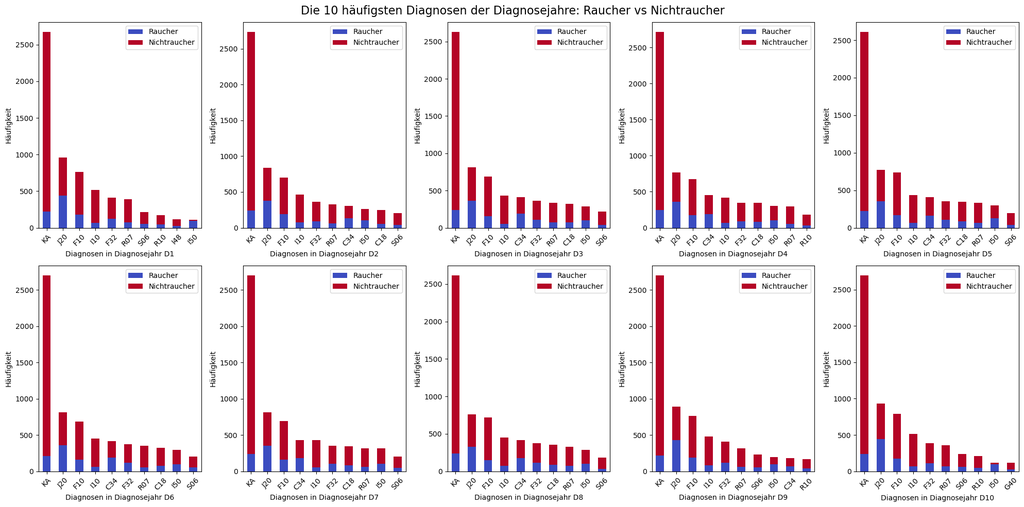

```python
# Grafik pro Diagnosejahr für den Vergleich Raucher vs Nichtraucher
fig, axes = plt.subplots(2, 5, figsize=(20, 10))
diagnoses_columns = ['D1', 'D2', 'D3', 'D4', 'D5', 'D6', 'D7', 'D8', 'D9', 'D10']
smokers = dfdiagnoses_raw[dfdiagnoses_raw['Raucherstatus'] == 'Raucher']
non_smokers = dfdiagnoses_raw[dfdiagnoses_raw['Raucherstatus'] == 'Nichtraucher']

# Bestimmen der Häufigkeiten der einzelnen Diagnosen in den Jahren 1-10
for i, col in enumerate(diagnoses_columns):
    smokers_diagnoses_counts = smokers[col].value_counts()
    non_smokers_diagnoses_counts = non_smokers[col].value_counts()

    # Zusammenfügen der Anzahlen
    diagnoses_count_df = pd.DataFrame({'Smokers': smokers_diagnoses_counts, 'Non-Smokers': non_smokers_diagnoses_counts}).fillna(0)

    # Addieren der einzelnen Diagnosen der Raucher und Nichtraucher um eine Gesamtanzahl der Diagnose zu erhalten
    diagnoses_count_df['Total'] = diagnoses_count_df['Smokers'] + diagnoses_count_df['Non-Smokers']

    # Absteigende Sortierung um Top10 der Krankheiten pro Diagnosejahr herauszufiltern
    diagnoses_count_df_sorted = diagnoses_count_df.sort_values(by='Total', ascending=False).head(10)

    # Plotten der häufigsten Diagnosen pro Jahr, Raucher vs Nichtraucher
    ax = axes[i // 5, i % 5]
    diagnoses_count_df_sorted[['Smokers', 'Non-Smokers']].plot(kind='bar', stacked=True, ax=ax, colormap='coolwarm')
    ax.set_xlabel(f'Diagnosen in Diagnosejahr {col}')
    ax.set_ylabel('Häufigkeit')
    ax.set_xticklabels(ax.get_xticklabels(), rotation=45)
    ax.legend(['Raucher', 'Nichtraucher'])

fig.suptitle('Die 10 häufigsten Diagnosen der Diagnosejahre: Raucher vs Nichtraucher', fontsize=16)
plt.tight_layout()
plt.show()
```

Kommentar: Man erkennt deutlich, dass KA die häufigste Diagnose in jedem Diagnosejahr ist. Dies bedeutet, dort sind keine Krankheiten erfasst worden. Zudem finden sich in den Top 5 Diagnosen in jedem Jahr J20, F10, I10 und F32 wieder. Die Diagnosen in D7-D10 variieren pro Jahr.  
Auf den ersten Blick scheint es, als würden die Diagnosen der Nichtraucher überwiegen. Hier gilt es zu beachten, dass es deutlich mehr Nichtraucher im Datensatz gibt, sodass hier höhere Balken nicht direkt aussagekräftig sind.  
Dafür werden im Folgenden die Diagnosen KA, J20 und C34 genauer angeschaut.

```python
# Dictionaries um die Anzahlen der KA Diagnose zu speichern
ka_diagnosis_relative_smokers = {}
ka_diagnosis_relative_non_smokers = {}

# Relative Anteile pro Diagnosejahr für die Diagnose KA
for col in diagnoses_columns:
    # Berechnen der relativen Anteile der KA Diagnosen für Raucher
    count_smokers = len(smokers)
    ka_diagnosis_smokers = smokers[col].value_counts().get('KA', 0)
    ka_diagnosis_relative_smokers[col] = ka_diagnosis_smokers / count_smokers

    # Berechnen der relativen Anteile der KA Diagnosen für Nichtraucher
    count_non_smokers = len(non_smokers)
    ka_diagnosis_non_smokers = non_smokers[col].value_counts().get('KA', 0)
    ka_diagnosis_relative_non_smokers[col] = ka_diagnosis_non_smokers / count_non_smokers

# Ausgabe der relativen Anteile Raucher vs Nichtraucher
print(f"Relative Anteile der Raucher mit der Diagnose 'KA' in D1-D10: ")
for col, value in ka_diagnosis_relative_smokers.items():
    print(f"Diagnosejahr {col}: {value:.2%}")

print(f"\nRelative Anteile der Nichtraucher mit der Diagnose 'KA' in D1-D10: ")
for col, value in ka_diagnosis_relative_non_smokers.items():
    print(f"Diagnosejahr {col}: {value:.2%}")
```

```
Relative Anteile der Raucher mit der Diagnose 'KA' in D1-D10:
Diagnosejahr D1: 10.70%
Diagnosejahr D2: 11.76%
Diagnosejahr D3: 11.42%
Diagnosejahr D4: 11.91%
Diagnosejahr D5: 10.70%
Diagnosejahr D6: 10.02%
Diagnosejahr D7: 11.47%
Diagnosejahr D8: 11.62%
Diagnosejahr D9: 10.60%
Diagnosejahr D10: 11.37%

Relative Anteile der Nichtraucher mit der Diagnose 'KA' in D1-D10:
Diagnosejahr D1: 30.94%
Diagnosejahr D2: 31.43%
Diagnosejahr D3: 30.18%
Diagnosejahr D4: 31.13%
Diagnosejahr D5: 30.13%
Diagnosejahr D6: 31.42%
Diagnosejahr D7: 31.06%
Diagnosejahr D8: 29.95%
Diagnosejahr D9: 31.28%
Diagnosejahr D10: 31.01%
```

Kommentar: Bei den relativen Anteilen erkennt man sehr gut, dass der Anteil der KA Diagnosen unter den Nichtrauchern dreifach so hoch liegt, wie bei den Rauchern. Somit haben die Raucher häufiger erfasste Erkrankungen, als die Nichtraucher.

Achten Sie insbesondere auf akute Bronchitis (J20) und Lungenkrebs (C34).

```python
# Berechnung der relative Anteile für Raucher und Nichtraucher für akute Bronchitis (J20)
# Diagnose nur einmal pro Historie zählen
diagnosis_bronchitis_smokers = smokers['Historie'].str.contains('J20').sum()/smokers.shape[0]
diagnosis_bronchitis_non_smokers = non_smokers['Historie'].str.contains('J20').sum()/non_smokers.shape[0]

# Berechnung der relative Anteile für Raucher und Nichtraucher für Lungenkrebs (C34)
# Diagnose nur einmal pro Historie zählen
diagnosis_lung_cancer_smokers = smokers['Historie'].str.contains('C34').sum()/smokers.shape[0]
diagnosis_lung_cancer_non_smokers = non_smokers['Historie'].str.contains('C34').sum()/non_smokers.shape[0]

# Ausgabe der relativen Anzahlen Raucher vs Nichtraucher
print(f"Relative Anzahl der Raucher mit mindestens einer akuten Bronchitis (J20): {100*diagnosis_bronchitis_smokers:.2f}%")
print(f"Relative Anzahl der Nichtraucher mit mindestens einer akuten Bronchitis (J20): {100*diagnosis_bronchitis_non_smokers:.2f}%")
print(f"\nRelative Anzahl der Raucher mit mindestens einer Lungenkrebs Erkrankung (C34): {100*diagnosis_lung_cancer_smokers:.2f}%")
print(f"Relative Anzahl der Nichtraucher mit mindestens einer Lungenkrebs Erkrankung (C34): {100*diagnosis_lung_cancer_non_smokers:.2f}%")
```

```
Relative Anzahl der Raucher mit mindestens einer akuten Bronchitis (J20): 82.48%
Relative Anzahl der Nichtraucher mit mindestens einer akuten Bronchitis (J20): 43.42%

Relative Anzahl der Raucher mit mindestens einer Lungenkrebs Erkrankung (C34): 49.27%
Relative Anzahl der Nichtraucher mit mindestens einer Lungenkrebs Erkrankung (C34): 20.57%
```

Kommentar: Man erkennt, dass sowohl bei der Diagnose Lungenkrebs als auch bei akuter Bronchitis der Anteil der Raucher doppelt so hoch ist, wie der Anteil der Nichtraucher. Somit erkranken Raucher deutlich häufiger mindestens einmal in den Jahren 1-10 an diesen beiden Krankheiten. 80 Prozent der Raucher erkranken mindesten einmal an Bronchitis.  
Im Folgenden schauen wir uns an, ob Raucher auch häufiger an der selben Krankheit erkranken wie Nichtraucher.

```python
# Berechnung der relative Anteile für Raucher und Nichtraucher für mind. 2 akute Bronchitiden (J20)
diagnosis_bronchitis_smokers_2_times = smokers['Historie'].apply(lambda x: x.count('J20') >= 2).sum()/smokers.shape[0]
diagnosis_bronchitis_non_smokers_2_times = non_smokers['Historie'].apply(lambda x: x.count('J20') >= 2).sum()/non_smokers.shape[0]

# Berechnung der relative Anteile für Raucher und Nichtraucher für mind. 2 Lungenkrebs Erkrankungen (C34)
diagnosis_lung_cancer_smokers_2_times = smokers['Historie'].apply(lambda x: x.count('C34') >= 2).sum()/smokers.shape[0]
diagnosis_lung_cancer_non_smokers_2_times = non_smokers['Historie'].apply(lambda x: x.count('C34') >= 2).sum()/non_smokers.shape[0]

# Ausgabe der relativen Anzahlen Raucher vs Nichtraucher
print(f"Relative Anzahl der Raucher mit zwei oder mehr akuten Bronchitiden (J20): {100*diagnosis_bronchitis_smokers_2_times:.2f}%")
print(f"Relative Anzahl der Nichtraucher mit zwei oder mehr akuten Bronchitiden (J20): {100*diagnosis_bronchitis_non_smokers_2_times:.2f}%")
print(f"\nRelative Anzahl der Raucher mit zwei oder mehr Lungenkrebs Erkrankungen (C34): {100*diagnosis_lung_cancer_smokers_2_times:.2f}%")
print(f"Relative Anzahl der Nichtraucher mit zwei oder mehr Lungenkrebs Erkrankungen (C34): {100*diagnosis_lung_cancer_non_smokers_2_times:.2f}%")
```

```
Relative Anzahl der Raucher mit zwei oder mehr akuten Bronchitiden (J20): 56.24%
Relative Anzahl der Nichtraucher mit zwei oder mehr akuten Bronchitiden (J20): 11.49%

Relative Anzahl der Raucher mit zwei oder mehr Lungenkrebs Erkrankungen (C34): 12.92%
Relative Anzahl der Nichtraucher mit zwei oder mehr Lungenkrebs Erkrankungen (C34): 1.97%
```

Kommentar: Die Nichtraucher haben sehr selten zwei auftretende Lungenkrebs Erkrankungen innerhalb der Diagnosejahre D1-D10. Hingegen liegt dieser Prozentsatz der Raucher bei ca. 13 Prozent.  
Bei den akuten Bronchitiden bekommt jeder zweite Raucher 2 oder mehr Erkrankungen dieser Art. Bei den Nichtrauchern ist es nur ca. jeder Zehnte.

Wie wahrscheinlich ist es, dass ein junger Kunde (<= 30 Jahre) eine Historie hat, in der mindestens einmal “KA” auftritt? Vergleichen Sie mit dem Altersbereich (>30 und <=50 Jahre) bzw. dem Altersbereich (>50).

```python
# Wahrscheinlichkeit für "KA" innerhalb einer definierten Altersgruppe
# Definieren der Altersgruppen
young_group = dfdiagnoses_raw[dfdiagnoses_raw['Alter'] <= 30]
middle_group = dfdiagnoses_raw[(dfdiagnoses_raw['Alter'] > 30) & (dfdiagnoses_raw['Alter'] <= 50)]
old_group = dfdiagnoses_raw[dfdiagnoses_raw['Alter'] > 50]

# Berechnen der Wahrscheinlichkeit
prob_young = calculate_probability_from_history(young_group, 'KA')
prob_middle = calculate_probability_from_history(middle_group, 'KA')
prob_old = calculate_probability_from_history(old_group, 'KA')

# Ausgabe der Wahrscheinlichkeiten
print(f"Wahrscheinlichkeit bei jungen Kunden (<= 30 Jahre), dass mind. einmal KA in der Historie auftritt: {100*prob_young:.2f}%")
print(f"Wahrscheinlichkeit bei mittelalten Kunden (> 30 und <= 50 Jahre), dass mind. einmal KA in der Historie auftritt: {100*prob_middle:.2f}%")
print(f"Wahrscheinlichkeit bei alten Kunden (> 50 Jahre), dass mind. einmal KA in der Historie auftritt: {100*prob_old:.2f}%")
```

```
Wahrscheinlichkeit bei jungen Kunden (<= 30 Jahre), dass mind. einmal KA in der Historie auftritt: 97.18%
Wahrscheinlichkeit bei mittelalten Kunden (> 30 und <= 50 Jahre), dass mind. einmal KA in der Historie auftritt: 88.51%
Wahrscheinlichkeit bei alten Kunden (> 50 Jahre), dass mind. einmal KA in der Historie auftritt: 63.86%
```

Kommentar: Je jünger die Kunden sind, desto wahrscheinlicher ist es, mindestens einmal die Diagnose KA (keine Angabe) zu erhalten.

Erstellen Sie eine Übersicht der historischen Diagnosen, um eine bessere Übersicht zu bekommen.

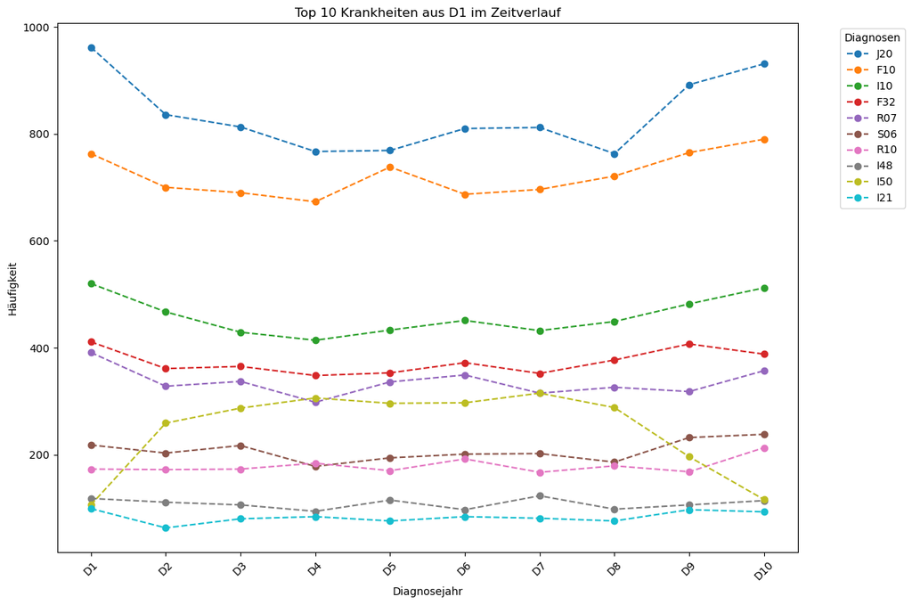

```python
# Dictionary für die Anzahlen pro Diagnosen
diagnosis_counts = {diagnosis: [] for diagnosis in top_10_diseases.index}

# Anzahlen der Top 10 Krankheiten aus dem ersten Diagnosejahr für alle Diagnosejahre speichern
for col in diagnoses_columns:
    for diagnosis in top_10_diseases.index:
        diagnosis_counts[diagnosis].append(dfdiagnoses_raw[col].value_counts().get(diagnosis, 0))

# Plotten der Anzahlen über alle Diagnosejahre
plt.figure(figsize=(12, 8))
for diagnosis, counts in diagnosis_counts.items():
    plt.plot(diagnoses_columns, counts, linestyle='--', marker='o', label=diagnosis)

# Plotten
plt.title('Top 10 Krankheiten aus D1 im Zeitverlauf')
plt.xlabel('Diagnosejahr')
plt.ylabel('Häufigkeit')
plt.xticks(rotation=45)
plt.legend(title='Diagnosen', bbox_to_anchor=(1.05, 1), loc='upper left')
plt.tight_layout()
```

Kommentar: Die meisten Diagnosen bleiben über den Zeitverlauf recht stabil. Die größten Schwankungen erkennt man bei den Diagnosen J20, F10 und I50. Insbesondere bei I50 (Herzinsuffizienz) steigen die Zahlen ab Diagnosejahr D1 an und sinken ab D8 wieder stark ab.

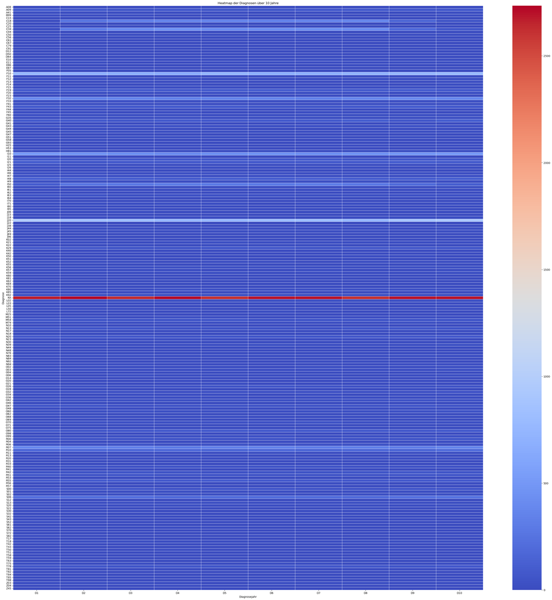

```python
# Häufigkeit der Diagnosen über alle Diagnosejahre als Heatmap
heatmap_diagnoses = dfdiagnoses_raw[diagnoses_columns]
plt.figure(figsize=(40, 40))
sns.heatmap(heatmap_diagnoses.apply(pd.Series.value_counts).fillna(0), cmap='coolwarm', linewidths=0.5)
plt.title('Heatmap der Diagnosen über 10 Jahre')
plt.xlabel('Diagnosejahr')
plt.ylabel('Diagnose')
plt.show()
```

Kommentar: Diese Heatmap dient gut als allgemeine Übersicht über die Diagnosen im 10-Jahresverlauf. Man erkennt, dass viele Krankheiten recht selten vorkommen, einige mittelmäßig und nur die Diagnose 'keine Angabe' sticht mit der roten Farbe hervor. Hier ist ein sehr großes Vorkommniss zu deuten.  
Insbesondere erkennt man auch, dass die Diagnosehäufigkeit über die Jahre in den meisten Fällen recht konstant bleibt (kein großer Farbverlauf).

### Aufgabe 2. [Textbasiertes neuronales Netz] [35 Punkte]

Entwickeln Sie ein neuronales Netz als “Language Model”, welches textbasierte Vorhersagen zu einer Person unter Berücksichtigung der medizinischen Historie erstellt. Die medizinische Historie soll als “Satz” aufgefasst werden und das Modell soll die nächsten “Wörter” (Diagnosen) dieses “Satzes” fortschreiben bzw. vorhersagen.

#### (a) Datenaufbereitung

Die medizinischen Historien aller Kunden sollen gemeinsam betrachtet werden. Die einzelnen “Sätze” werden also in einen gemeinsamen, längeren “Text” geschrieben. Prognosen werden jeweils nur innerhalb eines “Satzes” getroffen. Diskretisieren Sie den Text für die weitere Verarbeitung mit Hilfe eines Tokenizers. Wählen Sie dabei eine zur Fragestellung passende Größe des Vokabulars. Im weiteren Verlauf möchten Sie nun aus vier Diagnosen die nun folgende fünfte Diagnose vorhersagen. Zerlegen Sie dazu den Text rollierend in Elemente der Länge 5 (N-Gram-Sequence). Führen Sie diese anschließend in eine Tabelle zusammen. Je versicherter Person entstehen durch diese Vorgehensweise aus den vorliegenden 10 Diagnosen 6 Beobachtungen für die Modellbildung. Bereiten Sie den Datensatz für das “Language Model” vor. Zerlegen Sie den Datensatz in Training und Test (stratifiziert).

```python
# Kombinieren aller Historien zu einem gemeinsamen, längeren "Text"
histories = dfdiagnoses_encoded['Historie'].tolist()
text = ' '.join(histories)

# Text mit Hilfe des Tokenizers "tokenisieren"
tokenizer = Tokenizer()
tokenizer.fit_on_texts([text])

# Hinzufügen des Null-Tokens, da Zuordnung bei 1 beginnt
total_words = len(tokenizer.word_index) + 1

# N-Gram-Sequenzen erstellen
input_sequences = []
for line in histories:
    token_list = tokenizer.texts_to_sequences([line])[0]
    for i in range(4, len(token_list)):
        n_gram_sequence = token_list[i-4:i+1]
        input_sequences.append(n_gram_sequence)

# Sequenzen auffüllen, padding um die Sequenzen auf dieselbe Länge zu bringen (durch Auffüllen von Nullen)
max_sequence_len = max([len(x) for x in input_sequences])
input_sequences = np.array(pad_sequences(input_sequences, maxlen=max_sequence_len, padding='pre'))

# Daten in Prädiktoren und Label aufteilen
X_diagnoses, y = input_sequences[:,:-1], input_sequences[:,-1]

# Labels mit One-Hot Encoding encoden
y_1d = y
y = to_categorical(y, num_classes=total_words)

# Sequenzen mit den entsprechenden Werten des Alters, Geschlechts und BMI auffüllen (6 Beobachtungssequenzen, 6 mal die Werte)
# Altersverschiebung (startend bei 0) um es später im neuronalen Netz nutzen zu können
X_age = np.repeat(dfdiagnoses_encoded['Alter'].values-min(dfdiagnoses_encoded['Alter']), 6)
X_gender = np.repeat(dfdiagnoses_encoded['Geschlecht'].values, 6)
X_bmi = np.repeat(dfdiagnoses_encoded['BMI'].values, 6)

# Sicherstellen, dass jede Klasse mindestens zwei Datenpunkte hat, sodass wir im neuronalen Netz mit gültigen Daten trainieren und testen können
class_counts = np.sum(y, axis=0)
valid_classes = np.where(class_counts >= 2)[0]
valid_indices = np.isin(np.argmax(y, axis=1), valid_classes)

# Rausstreichen aller "ungültigen" Reihen
X_diagnoses, y = X_diagnoses[valid_indices], y[valid_indices]
X_age, X_gender, X_bmi = X_age[valid_indices], X_gender[valid_indices], X_bmi[valid_indices]


# Datensatz in Training und Test aufteilen, hier stratifizieren
X_diagnoses_train, X_diagnoses_test, y_train, y_test = train_test_split(X_diagnoses, y, test_size=0.2, stratify=y, random_state=set_seed)
X_age_train, X_age_test = train_test_split(X_age, test_size=0.2, stratify=y, random_state=set_seed)
X_gender_train, X_gender_test = train_test_split(X_gender, test_size=0.2, stratify=y, random_state=set_seed)
X_bmi_train, X_bmi_test = train_test_split(X_bmi, test_size=0.2, stratify=y, random_state=set_seed)
```

#### (b) Neuronales Netz

Definieren Sie ein neuronales Netz und kalibrieren Sie dieses. Wählen Sie eine geeignete Parametrisierung (Hinweis: ein ausführliches Parameter-Tuning ist nicht notwendig). Das Modell soll aus vier Diagnosen die nun folgende fünfte Diagnose vorhersagen. Berücksichtigen Sie folgende Modellstruktur:

Eingabeschicht:

- vergangene Diagnosen  
  o ein Embedding um die Dimension des Vokabulars zu reduzie-ren (Output-Dimension 2)  
  o mehrere LSTM-Units um die sequentielle Struktur der medizi-nischen Information abzudecken
- Informationen zur versicherten Person  
  o je ein Embedding für das Alter, das Geschlecht und den BMI (Output-Dimension jeweils 2)

Zwischenschicht:

- mind. einen weiteren Layer mit Regularisierung

Ausgabeschicht:

- Ausgabe von Wahrscheinlichkeiten für alle Diagnosen.

Geben Sie die Modellstruktur aus und kalibrieren Sie anschließend das Modell.

```python
# Neuronales Netz definieren
# Eingabeschichten
input_diagnoses = Input(shape=(max_sequence_len-1,), name='input_diagnoses')
input_age = Input(shape=(1,), name='input_age')
input_gender = Input(shape=(1,), name='input_gender')
input_bmi = Input(shape=(1,), name='input_bmi')

# Embedding-Schichten
embedding_diagnoses = Embedding(input_dim=total_words, output_dim=2, name='embedding_diagnoses')(input_diagnoses)
embedding_age = Embedding(input_dim=max(X_age)+1, output_dim=2, name='embedding_age')(input_age)
embedding_gender = Embedding(input_dim=2, output_dim=2, name='embedding_gender')(input_gender)
embedding_bmi = Embedding(input_dim=3, output_dim=2, name='embedding_bmi')(input_bmi)

# LSTM-Schicht für Diagnosen
lstm_diagnoses = LSTM(300, return_sequences=True, name='lstm_1')(embedding_diagnoses)
lstm_diagnoses = LSTM(150, name='lstm_2')(lstm_diagnoses)

# Embeddings flachen
flatten_age = Flatten(name='flatten_age')(embedding_age)
flatten_gender = Flatten(name='flatten_gender')(embedding_gender)
flatten_bmi = Flatten(name='flatten_bmi')(embedding_bmi)

# Alle Merkmale zusammenführen
concatenated_features = Concatenate(name='concatenate')([lstm_diagnoses, flatten_age, flatten_gender, flatten_bmi])

# Zwischenschicht mit Regularisierung
intermediate_layer = Dense(200, activation='relu', kernel_regularizer='l2',name='intermediate_layer')(concatenated_features)
intermediate_layer = Dropout(0.2, name='dropout_layer')(intermediate_layer)

# Ausgabeschicht
output_layer = Dense(total_words, activation='softmax', name='output')(intermediate_layer)

# Modell definieren
model = Model(inputs=[input_diagnoses, input_age, input_gender, input_bmi], outputs=output_layer)

# Modell kompilieren
model.compile(loss='categorical_crossentropy', optimizer='adam', metrics=['auc'])

# Early Stopping einfügen, falls Modell sich 3 Epochen nicht verbessert
early_stopping = EarlyStopping(monitor='val_loss', patience=3, restore_best_weights=True)

# Modellübersicht anzeigen
model.summary()

# Modell trainieren
history = model.fit([X_diagnoses_train, X_age_train, X_gender_train, X_bmi_train], y_train,
                    epochs=50,
                    batch_size=64,
                    verbose=1,
                    validation_data=([X_diagnoses_test, X_age_test, X_gender_test, X_bmi_test], y_test),
                    callbacks=[early_stopping])
```

```
Model: "functional"
```

```
┏━━━━━━━━━━━━━━━━━━━━━┳━━━━━━━━━━━━━━━━━━━┳━━━━━━━━━━━━┳━━━━━━━━━━━━━━━━━━━┓
┃ Layer (type)        ┃ Output Shape      ┃    Param # ┃ Connected to      ┃
┡━━━━━━━━━━━━━━━━━━━━━╇━━━━━━━━━━━━━━━━━━━╇━━━━━━━━━━━━╇━━━━━━━━━━━━━━━━━━━┩
│ input_diagnoses     │ (None, 4)         │          0 │ -                 │
│ (InputLayer)        │                   │            │                   │
├─────────────────────┼───────────────────┼────────────┼───────────────────┤
│ embedding_diagnoses │ (None, 4, 2)      │        424 │ input_diagnoses[… │
│ (Embedding)         │                   │            │                   │
├─────────────────────┼───────────────────┼────────────┼───────────────────┤
│ input_age           │ (None, 1)         │          0 │ -                 │
│ (InputLayer)        │                   │            │                   │
├─────────────────────┼───────────────────┼────────────┼───────────────────┤
│ input_gender        │ (None, 1)         │          0 │ -                 │
│ (InputLayer)        │                   │            │                   │
├─────────────────────┼───────────────────┼────────────┼───────────────────┤
│ input_bmi           │ (None, 1)         │          0 │ -                 │
│ (InputLayer)        │                   │            │                   │
├─────────────────────┼───────────────────┼────────────┼───────────────────┤
│ lstm_1 (LSTM)       │ (None, 4, 300)    │    363,600 │ embedding_diagno… │
├─────────────────────┼───────────────────┼────────────┼───────────────────┤
│ embedding_age       │ (None, 1, 2)      │         94 │ input_age[0][0]   │
│ (Embedding)         │                   │            │                   │
├─────────────────────┼───────────────────┼────────────┼───────────────────┤
│ embedding_gender    │ (None, 1, 2)      │          4 │ input_gender[0][… │
│ (Embedding)         │                   │            │                   │
├─────────────────────┼───────────────────┼────────────┼───────────────────┤
│ embedding_bmi       │ (None, 1, 2)      │          6 │ input_bmi[0][0]   │
│ (Embedding)         │                   │            │                   │
├─────────────────────┼───────────────────┼────────────┼───────────────────┤
│ lstm_2 (LSTM)       │ (None, 150)       │    270,600 │ lstm_1[0][0]      │
├─────────────────────┼───────────────────┼────────────┼───────────────────┤
│ flatten_age         │ (None, 2)         │          0 │ embedding_age[0]… │
│ (Flatten)           │                   │            │                   │
├─────────────────────┼───────────────────┼────────────┼───────────────────┤
│ flatten_gender      │ (None, 2)         │          0 │ embedding_gender… │
│ (Flatten)           │                   │            │                   │
├─────────────────────┼───────────────────┼────────────┼───────────────────┤
│ flatten_bmi         │ (None, 2)         │          0 │ embedding_bmi[0]… │
│ (Flatten)           │                   │            │                   │
├─────────────────────┼───────────────────┼────────────┼───────────────────┤
│ concatenate         │ (None, 156)       │          0 │ lstm_2[0][0],     │
│ (Concatenate)       │                   │            │ flatten_age[0][0… │
│                     │                   │            │ flatten_gender[0… │
│                     │                   │            │ flatten_bmi[0][0] │
├─────────────────────┼───────────────────┼────────────┼───────────────────┤
│ intermediate_layer  │ (None, 200)       │     31,400 │ concatenate[0][0] │
│ (Dense)             │                   │            │                   │
├─────────────────────┼───────────────────┼────────────┼───────────────────┤
│ dropout_layer       │ (None, 200)       │          0 │ intermediate_lay… │
│ (Dropout)           │                   │            │                   │
├─────────────────────┼───────────────────┼────────────┼───────────────────┤
│ output (Dense)      │ (None, 212)       │     42,612 │ dropout_layer[0]… │
└─────────────────────┴───────────────────┴────────────┴───────────────────┘
```

```
 Total params: 708,740 (2.70 MB)
```

```
 Trainable params: 708,740 (2.70 MB)
```

```
 Non-trainable params: 0 (0.00 B)
```

```
750/750 ━━━━━━━━━━━━━━━━━━━━ 17s 19ms/step - auc: 0.8331 - loss: 4.1961 - val_auc: 0.8623 - val_loss: 3.5193
750/750 ━━━━━━━━━━━━━━━━━━━━ 14s 18ms/step - auc: 0.8677 - loss: 3.4762 - val_auc: 0.8726 - val_loss: 3.3751
750/750 ━━━━━━━━━━━━━━━━━━━━ 16s 21ms/step - auc: 0.8765 - loss: 3.3541 - val_auc: 0.8782 - val_loss: 3.3293
750/750 ━━━━━━━━━━━━━━━━━━━━ 19s 25ms/step - auc: 0.8797 - loss: 3.3136 - val_auc: 0.8795 - val_loss: 3.3050
750/750 ━━━━━━━━━━━━━━━━━━━━ 17s 22ms/step - auc: 0.8818 - loss: 3.2899 - val_auc: 0.8815 - val_loss: 3.2826
750/750 ━━━━━━━━━━━━━━━━━━━━ 15s 20ms/step - auc: 0.8828 - loss: 3.2685 - val_auc: 0.8826 - val_loss: 3.2670
750/750 ━━━━━━━━━━━━━━━━━━━━ 15s 20ms/step - auc: 0.8838 - loss: 3.2524 - val_auc: 0.8832 - val_loss: 3.2554
750/750 ━━━━━━━━━━━━━━━━━━━━ 18s 24ms/step - auc: 0.8843 - loss: 3.2400 - val_auc: 0.8841 - val_loss: 3.2470
750/750 ━━━━━━━━━━━━━━━━━━━━ 15s 20ms/step - auc: 0.8855 - loss: 3.2299 - val_auc: 0.8838 - val_loss: 3.2431
750/750 ━━━━━━━━━━━━━━━━━━━━ 14s 19ms/step - auc: 0.8860 - loss: 3.2209 - val_auc: 0.8840 - val_loss: 3.2375
750/750 ━━━━━━━━━━━━━━━━━━━━ 15s 19ms/step - auc: 0.8859 - loss: 3.2172 - val_auc: 0.8839 - val_loss: 3.2348
750/750 ━━━━━━━━━━━━━━━━━━━━ 19s 26ms/step - auc: 0.8862 - loss: 3.2092 - val_auc: 0.8840 - val_loss: 3.2320
750/750 ━━━━━━━━━━━━━━━━━━━━ 18s 24ms/step - auc: 0.8863 - loss: 3.2053 - val_auc: 0.8842 - val_loss: 3.2286
750/750 ━━━━━━━━━━━━━━━━━━━━ 16s 22ms/step - auc: 0.8864 - loss: 3.2010 - val_auc: 0.8841 - val_loss: 3.2275
750/750 ━━━━━━━━━━━━━━━━━━━━ 19s 25ms/step - auc: 0.8865 - loss: 3.1968 - val_auc: 0.8842 - val_loss: 3.2255
750/750 ━━━━━━━━━━━━━━━━━━━━ 16s 21ms/step - auc: 0.8876 - loss: 3.1938 - val_auc: 0.8843 - val_loss: 3.2233
750/750 ━━━━━━━━━━━━━━━━━━━━ 15s 20ms/step - auc: 0.8869 - loss: 3.1933 - val_auc: 0.8838 - val_loss: 3.2213
750/750 ━━━━━━━━━━━━━━━━━━━━ 15s 20ms/step - auc: 0.8870 - loss: 3.1878 - val_auc: 0.8838 - val_loss: 3.2201
750/750 ━━━━━━━━━━━━━━━━━━━━ 16s 22ms/step - auc: 0.8868 - loss: 3.1854 - val_auc: 0.8840 - val_loss: 3.2198
750/750 ━━━━━━━━━━━━━━━━━━━━ 17s 23ms/step - auc: 0.8875 - loss: 3.1815 - val_auc: 0.8846 - val_loss: 3.2207
750/750 ━━━━━━━━━━━━━━━━━━━━ 16s 21ms/step - auc: 0.8878 - loss: 3.1787 - val_auc: 0.8854 - val_loss: 3.2183
750/750 ━━━━━━━━━━━━━━━━━━━━ 15s 20ms/step - auc: 0.8876 - loss: 3.1767 - val_auc: 0.8847 - val_loss: 3.2211
750/750 ━━━━━━━━━━━━━━━━━━━━ 16s 22ms/step - auc: 0.8874 - loss: 3.1742 - val_auc: 0.8849 - val_loss: 3.2194
750/750 ━━━━━━━━━━━━━━━━━━━━ 16s 22ms/step - auc: 0.8881 - loss: 3.1722 - val_auc: 0.8851 - val_loss: 3.2207
```

Plausibilisieren und interpretieren Sie die Ergebnisse.

Kommentar: Die gewählte Performance Metrik ist hier 'AUC', die 'Area under Curve'. Je näher dieser Wert an der 1 liegt, desto besser sagt das Modell die Daten vorher. Da die Werte der Epochen mit ca. 0.89 (Training) bzw. ca. 0.88 (Validierung) oberhalb von 0.5 (zufälliges Raten) liegen, kann man hier sagen, dass das Modell relativ erfolgreiche Vorhersagen, sowohl auf den Trainings- als auch auf den Testdaten, machen kann.  
Die Variable 'loss' wird im Training des Modells minimiert. Je tiefer dieser Wert ist, desto besser ist das Modell. Da sich der validation loss ab Epoche 21 nicht mehr verbessert, stoppt das Modell vorzeitig nach Epoche 24 (Early Stopping) um zukünftiges Overfitting zu vermeiden. Da sich der loss der Trainingsdaten ungefähr auf der selben Höhe der Testdaten befindet, ist hier auch nicht von Overfitting auszugehen.

Erstellen Sie Modellvorhersagen und vergleichen Sie diese mit der empirischen Beobachtung. Nutzen Sie ein geeignetes Gütemaß, z.B. den Multiclass-AUC für Trainings- und Testdaten.

```python
# Erstellen von Modellvorhersagen
y_pred_train = model.predict([X_diagnoses_train, X_age_train, X_gender_train, X_bmi_train], verbose = 0)
y_pred_test = model.predict([X_diagnoses_test, X_age_test, X_gender_test, X_bmi_test], verbose = 0)

# Berechnen des Multiclass-AUCs auf Training und Testdaten
auc_train = roc_auc_score(y_train.flatten(), y_pred_train.flatten(), multi_class='ovr')
auc_test = roc_auc_score(y_test.flatten(), y_pred_test.flatten(), multi_class='ovr')

# Ausgabe der Ergebnisse
print(f"Der Multiclass AUC auf den Trainingsdaten beträgt: {auc_train}")
print(f"Der Multiclass AUC auf den Testdaten beträgt: {auc_test}")
```

```
Der Multiclass AUC auf den Trainingsdaten beträgt: 0.9367932022832872
Der Multiclass AUC auf den Testdaten beträgt: 0.933431484642701
```

Kommentar: Der Multiclass AUC Score ist sowohl auf den Trainings- als auch auf den Testdaten sehr nahe an 1. Dies bedeutet, dass das Modell die wahren Werte mit den Vorhersagen sehr gut trifft. Auch ist zu bemerken, dass der Multiclass AUC in beiden Fällen sehr nahe beieinander liegt, sodass man sagen kann, dass das Modell auch gut mit unbekannten Daten (Testdaten) umgehen kann und es keine zu große Überanpassung an die Trainingsdaten gibt.

#### (c) Eingeschränktes Neuronales Netz

Ziel ist es nun, die Prognose auf einzelne Krankheiten mit besonderer Schwere einzuschränken, um damit das Modell auf die geplante Anwendung maßzuschneidern. Ziel ist es bessere Prognosen zu erzielen. Nach intensiven Diskussionen mit ihren medizinischen Experten einigen Sie sich auf folgende Krankheiten für die Anwendung im Case Management:

• Chronische Herzinsuffizienz (ICD-10 Diagnose I50)

• Depression (ICD-10 Diagnose F32)

• Darmkrebs (ICD-10 Diagnose C18)

• Akute Bronchitis (ICD-10 Diagnose J20)

• Lungenkrebs (ICD-10 Diagnose C34)

Schränken Sie die Zielgröße entsprechend ein. Rekodieren Sie alle anderen Diagnosen auf “ka”.

```python
# Zielgröße einschränken auf die obigen Diagnosen
target_index = []
target_diagnoses = {'i50', 'f32', 'c18', 'j20', 'c34'}

# Alle anderen Diagnosen auf 'ka' rekodieren
for diagnose in target_diagnoses:
    target_index.append(tokenizer.word_index[diagnose])
input_sequences_new= np.where(np.isin(input_sequences, target_index), input_sequences, tokenizer.word_index['ka'])
```

Kommentar: Im vorherigen Modell wurden hier evtl. Zeilen durch fehlende Mindestanzahl von Datenpunkten in Klassen gelöscht. Somit ist eine erneute Initialisierung der Daten und neue Überprüfung der Mindestanzahl-Bedingung erforderlich.

```python
# Daten in Prädiktoren und Label aufteilen
X_diagnoses, y = input_sequences[:,:-1], input_sequences_new[:,-1]

# Labels mit One-Hot Encoding encoden
y = to_categorical(y, num_classes=total_words)

# Sequenzen mit den entsprechenden Werten des Alters, Geschlechts und BMI auffüllen (6 Beobachtungssequenzen, 6 mal die Werte)
# Altersverschiebung (startend bei 0) um es später im neuronalen Netz nutzen zu können
X_age = np.repeat(dfdiagnoses_encoded['Alter'].values-min(dfdiagnoses_encoded['Alter']), 6)
X_gender = np.repeat(dfdiagnoses_encoded['Geschlecht'].values, 6)
X_bmi = np.repeat(dfdiagnoses_encoded['BMI'].values, 6)

# Sicherstellen, dass jede Klasse mindestens zwei Datenpunkte hat, sodass wir im neuronalen Netz mit gültigen Daten trainieren und testen können
class_counts = np.sum(y, axis=0)
valid_classes = np.where(class_counts >= 2)[0]
valid_indices = np.isin(np.argmax(y, axis=1), valid_classes)

# Rausstreichen aller "ungültigen" Reihen
X_diagnoses, y = X_diagnoses[valid_indices], y[valid_indices]
X_age, X_gender, X_bmi = X_age[valid_indices], X_gender[valid_indices], X_bmi[valid_indices]

# Datensatz in Training und Test aufteilen, hier stratifizieren
X_diagnoses_train, X_diagnoses_test, y_train, y_test = train_test_split(X_diagnoses, y, test_size=0.2, stratify=y, random_state=set_seed)
X_age_train, X_age_test = train_test_split(X_age, test_size=0.2, stratify=y, random_state=set_seed)
X_gender_train, X_gender_test = train_test_split(X_gender, test_size=0.2, stratify=y, random_state=set_seed)
X_bmi_train, X_bmi_test  = train_test_split(X_bmi, test_size=0.2, stratify=y, random_state=set_seed)
```

Definieren Sie ein zweites neuronales Netz und kalibrieren Sie dieses. Wählen Sie eine geeignete Parametrisierung (Hinweis: ein ausführliches Parameter-Tuning ist nicht notwendig). Verwenden Sie die gleiche Modellstruktur wie in Aufgabe 2b. Verwenden Sie zusätzlich eine Gewichtung im Kalibrierungsschritt um die Unbalananciertheit in der Zielgröße zu berücksichtigten (z.B. ist ka nun deutlich überrepräsentiert).

```python
# eingeschränkte Krankheiten plus ka als Diagnose sind neue Zielvariable
target_diagnoses = {'ka', 'i50', 'f32', 'c18', 'j20', 'c34'}

# Erstellen leerer Liste für Zielindizes
target_index = []
target_cols_indices = []

# Füllen der Listen um Indizes zur Löschung unnötiger Spalten der Zielvariable zu befüllen
for diagnose in target_diagnoses:
    target_index.append(tokenizer.word_index[diagnose])

for i, col in enumerate(y_train.T):
    if any(np.isin(col, target_index)):
        target_cols_indices.append(i)

# Löschung nicht relevanter/leerer Spalten in der Zielvariable
y_train = y_train[:, target_cols_indices]
y_test = y_test[:, target_cols_indices]

# Berechnen der Gewichte der eingeschränkten Diagnosen um Zielgröße auszubalancieren
y_train_1d = np.argmax(y_train, axis=1)
unique_classes = np.unique(y_train_1d)
class_weights = class_weight.compute_class_weight('balanced', classes=unique_classes, y=y_train_1d)

# Speichern der Gewichte in einem Dictionary
class_weights_dict = dict(zip(unique_classes, class_weights))
```

```python
# Gewichte ausgeben
print(class_weights_dict)
```

```
{0: 0.20932485143590146, 1: 2.0080361627322953, 2: 4.444691495275153, 3: 5.205729166666667, 4: 6.376395534290271, 5: 6.630182421227198}
```

Kommentar: Die Gewichte erscheinen sinnvoll. Die Diagnose an erster Stelle ist die 'ka' Diagnose, welche übermäßig häufig durch die Rekodierung auftritt. Dementsprechend ist es sinnvoll diese Diagnose mit einem geringen Gewicht zu belegen (ca. 0.21). Hingegen werden die Krankheitsdiagnosen mit größeren Gewichten belegt, was eine gewisse Verhältnismäßigkeit zurück bringt.

```python
# Neuronales Netz definieren
# Eingabeschichten
input_diagnoses = Input(shape=(max_sequence_len-1,), name='input_diagnoses_restr')
input_age = Input(shape=(1,), name='input_age_restr')
input_gender = Input(shape=(1,), name='input_gender_restr')
input_bmi = Input(shape=(1,), name='input_bmi_restr')

# Embedding-Schichten
embedding_diagnoses = Embedding(total_words, 2,name='embedding_diagnoses_restr')(input_diagnoses)
embedding_age = Embedding(input_dim=max(X_age)+1, output_dim=2, name='embedding_age_restr')(input_age)
embedding_gender = Embedding(input_dim=2, output_dim=2, name='embedding_gender_restr')(input_gender)
embedding_bmi = Embedding(input_dim=3, output_dim=2, name='embedding_bmi_restr')(input_bmi)

# LSTM-Schicht für Diagnosen
lstm_diagnoses = LSTM(300, return_sequences=True, name='lstm_1_restr')(embedding_diagnoses)
lstm_diagnoses = LSTM(150, name='lstm_2_restr')(lstm_diagnoses)

# Embeddings flachen
flat_age = Flatten(name='flatten_age_restr')(embedding_age)
flat_gender = Flatten(name='flatten_gender_restr')(embedding_gender)
flat_bmi = Flatten(name='flatten_bmi_restr')(embedding_bmi)

# Alle Merkmale zusammenführen
concatenated_features = Concatenate(name='concatenate_restr')([lstm_diagnoses, flat_age, flat_gender, flat_bmi])

# Zwischenschicht mit Regularisierung
intermediate_layer = Dense(200, activation='relu', kernel_regularizer='l2',name='intermediate_layer_restr')(concatenated_features)
intermediate_layer = Dropout(0.2)(intermediate_layer)

# Ausgabeschicht
output_layer = Dense(y_train.shape[1], activation='softmax', name='output_restr')(intermediate_layer)

# Modell definieren
model_restr = Model(inputs=[input_diagnoses, input_age, input_gender, input_bmi], outputs=output_layer)

# Modell kompilieren
model_restr.compile(loss='categorical_crossentropy', optimizer='adam', metrics=['auc'])

# Early Stopping einfügen, falls Modell sich 3 Epochen nicht verbessert
early_stopping = EarlyStopping(monitor='val_loss', patience=3, restore_best_weights=True)

# Modellübersicht anzeigen
model_restr.summary()

# Modell trainieren
history = model_restr.fit([X_diagnoses_train, X_age_train, X_gender_train, X_bmi_train], y_train,
                    epochs=50,
                    batch_size=64,
                    verbose=1,
                    validation_data=([X_diagnoses_test, X_age_test, X_gender_test, X_bmi_test], y_test),
                    class_weight=class_weights_dict, callbacks=[early_stopping])
```

```
Model: "functional_1"
```

```
┏━━━━━━━━━━━━━━━━━━━━━┳━━━━━━━━━━━━━━━━━━━┳━━━━━━━━━━━━┳━━━━━━━━━━━━━━━━━━━┓
┃ Layer (type)        ┃ Output Shape      ┃    Param # ┃ Connected to      ┃
┡━━━━━━━━━━━━━━━━━━━━━╇━━━━━━━━━━━━━━━━━━━╇━━━━━━━━━━━━╇━━━━━━━━━━━━━━━━━━━┩
│ input_diagnoses_re… │ (None, 4)         │          0 │ -                 │
│ (InputLayer)        │                   │            │                   │
├─────────────────────┼───────────────────┼────────────┼───────────────────┤
│ embedding_diagnose… │ (None, 4, 2)      │        424 │ input_diagnoses_… │
│ (Embedding)         │                   │            │                   │
├─────────────────────┼───────────────────┼────────────┼───────────────────┤
│ input_age_restr     │ (None, 1)         │          0 │ -                 │
│ (InputLayer)        │                   │            │                   │
├─────────────────────┼───────────────────┼────────────┼───────────────────┤
│ input_gender_restr  │ (None, 1)         │          0 │ -                 │
│ (InputLayer)        │                   │            │                   │
├─────────────────────┼───────────────────┼────────────┼───────────────────┤
│ input_bmi_restr     │ (None, 1)         │          0 │ -                 │
│ (InputLayer)        │                   │            │                   │
├─────────────────────┼───────────────────┼────────────┼───────────────────┤
│ lstm_1_restr (LSTM) │ (None, 4, 300)    │    363,600 │ embedding_diagno… │
├─────────────────────┼───────────────────┼────────────┼───────────────────┤
│ embedding_age_restr │ (None, 1, 2)      │         94 │ input_age_restr[… │
│ (Embedding)         │                   │            │                   │
├─────────────────────┼───────────────────┼────────────┼───────────────────┤
│ embedding_gender_r… │ (None, 1, 2)      │          4 │ input_gender_res… │
│ (Embedding)         │                   │            │                   │
├─────────────────────┼───────────────────┼────────────┼───────────────────┤
│ embedding_bmi_restr │ (None, 1, 2)      │          6 │ input_bmi_restr[… │
│ (Embedding)         │                   │            │                   │
├─────────────────────┼───────────────────┼────────────┼───────────────────┤
│ lstm_2_restr (LSTM) │ (None, 150)       │    270,600 │ lstm_1_restr[0][… │
├─────────────────────┼───────────────────┼────────────┼───────────────────┤
│ flatten_age_restr   │ (None, 2)         │          0 │ embedding_age_re… │
│ (Flatten)           │                   │            │                   │
├─────────────────────┼───────────────────┼────────────┼───────────────────┤
│ flatten_gender_res… │ (None, 2)         │          0 │ embedding_gender… │
│ (Flatten)           │                   │            │                   │
├─────────────────────┼───────────────────┼────────────┼───────────────────┤
│ flatten_bmi_restr   │ (None, 2)         │          0 │ embedding_bmi_re… │
│ (Flatten)           │                   │            │                   │
├─────────────────────┼───────────────────┼────────────┼───────────────────┤
│ concatenate_restr   │ (None, 156)       │          0 │ lstm_2_restr[0][… │
│ (Concatenate)       │                   │            │ flatten_age_rest… │
│                     │                   │            │ flatten_gender_r… │
│                     │                   │            │ flatten_bmi_rest… │
├─────────────────────┼───────────────────┼────────────┼───────────────────┤
│ intermediate_layer… │ (None, 200)       │     31,400 │ concatenate_rest… │
│ (Dense)             │                   │            │                   │
├─────────────────────┼───────────────────┼────────────┼───────────────────┤
│ dropout (Dropout)   │ (None, 200)       │          0 │ intermediate_lay… │
├─────────────────────┼───────────────────┼────────────┼───────────────────┤
│ output_restr        │ (None, 6)         │      1,206 │ dropout[0][0]     │
│ (Dense)             │                   │            │                   │
└─────────────────────┴───────────────────┴────────────┴───────────────────┘
```

```
 Total params: 667,334 (2.55 MB)
```

```
 Trainable params: 667,334 (2.55 MB)
```

```
 Non-trainable params: 0 (0.00 B)
```

```
750/750 ━━━━━━━━━━━━━━━━━━━━ 21s 23ms/step - auc: 0.6403 - loss: 1.9697 - val_auc: 0.6675 - val_loss: 1.7098
750/750 ━━━━━━━━━━━━━━━━━━━━ 15s 19ms/step - auc: 0.7287 - loss: 1.3895 - val_auc: 0.7035 - val_loss: 1.6814
750/750 ━━━━━━━━━━━━━━━━━━━━ 14s 18ms/step - auc: 0.7502 - loss: 1.3172 - val_auc: 0.7149 - val_loss: 1.6696
750/750 ━━━━━━━━━━━━━━━━━━━━ 16s 22ms/step - auc: 0.7566 - loss: 1.2843 - val_auc: 0.7200 - val_loss: 1.6712
750/750 ━━━━━━━━━━━━━━━━━━━━ 16s 21ms/step - auc: 0.7585 - loss: 1.2624 - val_auc: 0.7225 - val_loss: 1.6690
750/750 ━━━━━━━━━━━━━━━━━━━━ 14s 19ms/step - auc: 0.7602 - loss: 1.2481 - val_auc: 0.7337 - val_loss: 1.6401
750/750 ━━━━━━━━━━━━━━━━━━━━ 15s 20ms/step - auc: 0.7625 - loss: 1.2342 - val_auc: 0.7273 - val_loss: 1.6612
750/750 ━━━━━━━━━━━━━━━━━━━━ 15s 19ms/step - auc: 0.7637 - loss: 1.2253 - val_auc: 0.7348 - val_loss: 1.6362
750/750 ━━━━━━━━━━━━━━━━━━━━ 16s 21ms/step - auc: 0.7648 - loss: 1.2193 - val_auc: 0.7398 - val_loss: 1.6264
750/750 ━━━━━━━━━━━━━━━━━━━━ 17s 23ms/step - auc: 0.7655 - loss: 1.2116 - val_auc: 0.7321 - val_loss: 1.6462
750/750 ━━━━━━━━━━━━━━━━━━━━ 17s 22ms/step - auc: 0.7666 - loss: 1.2028 - val_auc: 0.7361 - val_loss: 1.6378
750/750 ━━━━━━━━━━━━━━━━━━━━ 15s 20ms/step - auc: 0.7682 - loss: 1.1962 - val_auc: 0.7299 - val_loss: 1.6641
```

Plausibilisieren und interpretieren Sie die Ergebnisse.

Erstellen Sie Modellvorhersagen und vergleichen Sie diese mit der empirischen Beobachtung. Nutzen Sie ein geeignetes Gütemaß, z.B. den Multiclass-AUC für Trainings- und Testdaten.

```python
# Erstellen von Modellvorhersagen
y_restr_pred_train = model_restr.predict([X_diagnoses_train, X_age_train, X_gender_train, X_bmi_train], verbose = 0)
y_restr_pred_test = model_restr.predict([X_diagnoses_test, X_age_test, X_gender_test, X_bmi_test], verbose = 0)

# Berechnen des Multiclass-AUCs auf Training und Testdaten
auc_restr_train = roc_auc_score(y_train.flatten(), y_restr_pred_train.flatten(), multi_class='ovr')
auc_restr_test = roc_auc_score(y_test.flatten(), y_restr_pred_test.flatten(), multi_class='ovr')

# Ausgabe der Ergebnisse
print(f"Der Multiclass AUC auf den Trainingsdaten beträgt: {auc_restr_train}")
print(f"Der Multiclass AUC auf den Testdaten beträgt: {auc_restr_test}")
```

```
Der Multiclass AUC auf den Trainingsdaten beträgt: 0.7416197887240548
Der Multiclass AUC auf den Testdaten beträgt: 0.7398978760960715
```

Kommentar: Der Multiclass AUC Score ist sowohl auf den Trainings- als auch auf den Testdaten sehr nahe beieinander, sodass man sagen kann, dass das Modell auch gut mit unbekannten Daten (Testdaten) umgehen kann und es keine zu große Überanpassung an die Trainingsdaten gibt. Der Multiclass AUC Score liegt gut zwischen 0.5 und 1. Dies deutet darauf hin, dass das Modell die Vorhersagen ganz gut treffen kann, jedoch etwas ungenauer als das uneingeschränkte Modell zuvor.

### Aufgabe 3. [Modellanwendung und Interpretation] [30 Punkte]

#### (a) Anwendung des Modells zur Prognose

Welche Krankheiten sind laut Modell am wahrscheinlichsten, wenn zuvor  
• Bluthochdruck (ICD-10 Diagnose I10)  
• Alkoholmissbrauch (ICD-10 Diagnose F10)  
• Akute Bronchitis (ICD-10 Diagnose J20)  
• keine Erkrankung (kA)  
diagnostiziert wurde? Nutzen Sie hierfür exemplarisch einen 60 jährigen Mann mit BMI-Status “OK”.

```python
# Erstellung des "Patienten" nach obigen Angaben
X_pred = [np.array([[tokenizer.word_index['i10'],tokenizer.word_index['f10'],tokenizer.word_index['j20'],tokenizer.word_index['ka']]]),\
          np.array([60-min(dfdiagnoses_encoded['Alter'])]),np.array([0]),np.array([0])]

# Vorhersage für den Patienten
y_pred_client = model_restr.predict(X_pred, verbose = 0)

# Matching der Vorhersage zu den jeweiligen ICD-10-Codes
icd_10_diagnoses = []
for index in range(len(target_cols_indices)):
    for icd_10_code, token in tokenizer.word_index.items():
        # Vergleich der Zielprognose mit den jeweiligen ICD-10 Codes im Tokenizer
        if token == target_cols_indices[index]:
            icd_10_diagnosis = icd_10_code
            break

    # Hinzufügen der passenden Diagnose
    icd_10_diagnoses.append(icd_10_diagnosis)

# Ausgabe der Vorhersage mit Matching Diagnose <-> Wahrscheinlichkeit
prediction_client = pd.DataFrame(y_pred_client.T)
prediction_client['ICD-10 Diagnose'] = icd_10_diagnoses
prediction_client.columns = ['Wahrscheinlichkeit', 'ICD-10 Diagnose']
prediction_client_sorted = prediction_client.sort_values(by = 'Wahrscheinlichkeit', ascending=False).reset_index(drop=True)
print(prediction_client_sorted)
```

```
   Wahrscheinlichkeit ICD-10 Diagnose
0            0.417972             c34
1            0.234579             c18
2            0.129901             j20
3            0.111064              ka
4            0.092805             i50
5            0.013679             f32
```

Kommentar: Die Person hat im nächsten Jahr am wahrscheinlichsten Lungenkrebs (C34) mit ca. 40 Prozent Wahrscheinlichkeit. In absteigender Wahrscheinlichkeit sind dann Darmkrebs (C18), Akute Bronchitis (J20) und keine Angabe die nächstmöglichen Vorhersagen. Die beiden Erkrankungen chronische Herzinsuffizienz (I50) und Depression (F32) sind am unwahrscheinlichsten.

Lesen sie die Datei Neue_Kunden.csv ein.

```python
# Einlesen der Datei der neuen Kunden
file_path = '/Users/vanessadietze/Documents/Dokumente/Vanessa/DAV Ausbildung/ADS/ADS4/Abgabe/PRF3116_Aufgaben_D/Neue_Kunden.csv'
dfnewclients = pd.read_csv(file_path, delimiter = ',', decimal='.')
print(dfnewclients)
```

```
   ID Geschlecht     BMI Raucherstatus  Alter   D1   D2   D3   D4   D5   D6  \
0   5       Mann      ok  Nichtraucher     32  F10  G40  J20  S20  J20  C34
1  12       Frau      ok       Raucher     62  J20  I10  I50  J20  J20  C34
2  14       Frau  extrem  Nichtraucher     56  H25  I10   kA   kA  I50  J20
3  20       Mann  extrem       Raucher     30  J20   kA   kA  L02  I50  C34
4  30       Mann  extrem       Raucher     31  I50  K29  I46   kA  J20   kA

    D7   D8   D9  D10                                 Historie
0   kA   kA  T58  R07    f10 g40 j20 s20 j20 c34 ka ka t58 r07
1  H25  R55  J20  J20  j20 i10 i50 j20 j20 c34 h25 r55 j20 j20
2  I10  I50  J20  F10    h25 i10 ka ka i50 j20 i10 i50 j20 f10
3  J20  C34  L72  J20    j20 ka ka l02 i50 c34 j20 c34 l72 j20
4  F10  L02  F32  F32    i50 k29 i46 ka j20 ka f10 l02 f32 f32
```

```python
# Anlegen der neuen Kunden
dfnewclients_encoded = dfnewclients.copy(deep=True)

# einzelne Diagnosespalten und Raucherstatus im weiteren Verlauf nicht relevant
dfnewclients_encoded = dfnewclients_encoded.drop(columns= ['D1', 'D2', 'D3', 'D4','D5', 'D6','D7', 'D8','D9', 'D10', 'Raucherstatus'])

# Encoden der neuen Kunden nach den gleichen Kodierungen wie bereits oben
dfnewclients_encoded['Geschlecht'] = dfnewclients_encoded['Geschlecht'].map({'Mann': 0, 'Frau': 1})
dfnewclients_encoded['BMI'] = dfnewclients_encoded['BMI'].map({'ok': 0, 'schlecht': 1, 'extrem': 2})
print(dfnewclients_encoded)
```

```
   ID  Geschlecht  BMI  Alter                                 Historie
0   5           0    0     32    f10 g40 j20 s20 j20 c34 ka ka t58 r07
1  12           1    0     62  j20 i10 i50 j20 j20 c34 h25 r55 j20 j20
2  14           1    2     56    h25 i10 ka ka i50 j20 i10 i50 j20 f10
3  20           0    2     30    j20 ka ka l02 i50 c34 j20 c34 l72 j20
4  30           0    2     31    i50 k29 i46 ka j20 ka f10 l02 f32 f32
```

Welche Krankheit ist für den Krankheitsverlauf des ersten neuen Kunden aus dem Datensatz Neue_Kunden.csv am wahrscheinlichsten?

```python
# Rausschreiben der letzten 4 Diagnosen des ersten Kunden
last_diagnoses_historie = dfnewclients_encoded['Historie'][0].split(' ')[-4:]

# Erstellung des Kunden für die Vorhersage
X_pred_client1 = [np.array([[tokenizer.word_index[last_diagnoses_historie[0]],tokenizer.word_index[last_diagnoses_historie[1]],\
                         tokenizer.word_index[last_diagnoses_historie[2]],tokenizer.word_index[last_diagnoses_historie[3]]]]),\
              np.array([dfnewclients_encoded['Alter'][0]-min(dfdiagnoses_encoded['Alter'])]),\
              np.array([dfnewclients_encoded['Geschlecht'][0]]), np.array([dfnewclients_encoded['BMI'][0]])]

# Vorhersage des Modells für den Kunden
y_pred_client1 = model_restr.predict(X_pred_client1, verbose = 0)

# Ausgabe der Vorhersage mit Matching Diagnose <-> Wahrscheinlichkeit
prediction_client1 = pd.DataFrame(y_pred_client1.T)
prediction_client1['ICD-10_Diagnose'] = icd_10_diagnoses
prediction_client1.columns = ['Wahrscheinlichkeit', 'ICD-10 Diagnose']
prediction_client1_sorted = prediction_client1.sort_values(by = 'Wahrscheinlichkeit', ascending=False).reset_index(drop=True)
print(prediction_client1_sorted)
```

```
   Wahrscheinlichkeit ICD-10 Diagnose
0            0.369405              ka
1            0.253391             j20
2            0.154842             c18
3            0.110146             f32
4            0.076999             c34
5            0.035218             i50
```

Kommentar: Mit einer Wahrscheinlichkeit von ca. 36 Prozent hat der Kunde im folgenden Jahr eine Diagnose von 'ka' (keine Angabe). Die nächste wahrscheinliche Erkrankung wäre Akute Bronchitis (J20). Darunter folgen mit eher geringeren Wahrscheinlichkeiten die restlichen Prognosemöglichkeiten.

Diskutieren Sie die Anwendbarkeit des Modells in der Praxis.

Kommentar: Generell ist die Idee eines Prognosemodells keine Schlechte. In diesem konkreten Fall gibt es leider ein paar Problemfelder, die sich nicht so einfach mit der Praxis und der Realität übereinfinden. Ein erstes Problem ist bspw die Auswahl der Diagnosen. Es wird nur die schwerwiegendste Diagnose gespeichert. Es gibt keine Aussage zu doppelten Krankheiten, fortgeführten Krankheiten, wenn sie von einer schwerwiegenderen Krankheit überlagert werden und auch fehlt eine genauere Abgrenzung der Diagnose 'kA'. Hierbei stellt sich die Frage ob 'keine Angabe' wirklich bedeutet, dass die Person nicht krank war oder bedeutet es viel eher, dass die Person nicht krank beim Arzt war. Könnte es auch sein, dass hier ein Datenfehler bei der Praxis vorlag und somit falsch fehlende Werte als 'kA' gespeichert werden. Zudem ist der Schritt der Einschränkung eher praxisfern. Es gibt so eine große Vielfalt an Krankheiten, dass es schwer ist, diese durch 5 schwerwiegende abzuschätzen. Klar gibt es Krankheiten, wie bspw Erkältung, die nicht allzu relevant sind. Es ist schon sinnvoll sich auf relevantere Krankheiten zu spezifizieren, allerdings sollte hier eine deutlich größere Auswahl her. Bestimmt kann das Modell in wirklich spezifischen Anwendungsfällen, mit auch in der Praxis eingeschränkten Prognoseausgängen, eine gute Einschätzung liefern, aber für die allgemeine Anwendung in der Versicherung, ist es zu modellhaft bzw. theoretisch.

Sie wollen das Modell nutzen, um anhand von vorgegebenen Krankheiten den weiteren Krankheitsverlauf für mehrere Jahre vorherzusagen. Für die Schätzung der nächsten Krankheit nutzen Sie wie zuvor die Modellvorhersage für die bekannten Krankheiten. Für die darauffolgende Krankheit werden dann die bekannten Krankheiten und die zuvor geschätzte Krankheit genutzt (rollierend), usw. Für die Vorhersage einer konkreten Krankheit ziehen Sie zufällig eine der fünf Krankheiten bzw. keine Krankheit anhand der geschätzten Wahrscheinlichkeiten des Modells. Nutzen Sie die Krankheitshistorie der Kunden zwei bis fünf des Datensatzes Neue_Kunden.csv, um jeweils einen Krankheitsverlauf für weitere fünf Jahre vorherzusehen. Sind die Ergebnisse plausibel?

```python
# Rausschreiben der letzten 4 Diagnosen aller neuen Kunden (in den Jahren 7-10)
last_diagnoses_histories = dfnewclients_encoded['Historie'].apply(lambda x: x.split(' ')[-4:])

# Anhängen der relevanten Diagnosen für die Planung an den Datensatz, Diagnosen in Tokenindizes umgewandelt
dfnewclients_encoded['Historie_letzte4Jahre'] = pd.Series(tokenizer.texts_to_sequences(last_diagnoses_histories))
print(dfnewclients_encoded)
```

```
   ID  Geschlecht  BMI  Alter                                 Historie  \
0   5           0    0     32    f10 g40 j20 s20 j20 c34 ka ka t58 r07
1  12           1    0     62  j20 i10 i50 j20 j20 c34 h25 r55 j20 j20
2  14           1    2     56    h25 i10 ka ka i50 j20 i10 i50 j20 f10
3  20           0    2     30    j20 ka ka l02 i50 c34 j20 c34 l72 j20
4  30           0    2     31    i50 k29 i46 ka j20 ka f10 l02 f32 f32

  Historie_letzte4Jahre
0        [1, 1, 139, 6]
1        [90, 13, 2, 2]
2          [4, 9, 2, 3]
3        [2, 7, 152, 2]
4         [3, 44, 5, 5]
```

```python
# zur Reproduzierbarkeit, globaler Seed wird sonst nicht genutzt
random.seed(set_seed)

# Vorrollen der Krankheitsprognosen für die nächsten 5 Jahre
# für die Kunden 2 bis 5
for client in range(1,5):
    # Liste für die Vorhersagen
    predictions = []

    # Vorhersagen für die nächsten 5 Jahre
    for year in range(5):
        # Erstellung des Kunden mit der jeweiligen 4-Jahreshistorie
        X_pred_clients = [np.array([dfnewclients_encoded['Historie_letzte4Jahre'].iloc[client]]),
                      np.array([dfnewclients_encoded['Alter'].iloc[client]-min(dfdiagnoses_encoded['Alter'])]),
                      np.array([dfnewclients_encoded['Geschlecht'].iloc[client]]),
                      np.array([dfnewclients_encoded['BMI'].iloc[client]])]

        #Vorhersage für das folgende Jahr
        y_pred_clients = model_restr.predict(X_pred_clients, verbose=0)
        prediction_clients = pd.DataFrame(y_pred_clients.T)
        prediction_clients['ICD-10 Diagnose'] = icd_10_diagnoses
        prediction_clients.columns= ['Wahrscheinlichkeit', 'ICD-10 Diagnose']

        # Zufälliges Ziehen einer der 5 Krankheiten oder ka, gewichtet mit den entsprechend vorhergesagten Wahrscheinlichkeiten
        selected_diagnosis = random.choices(prediction_clients['ICD-10 Diagnose'], weights=prediction_clients['Wahrscheinlichkeit'], k=1)[0]
        predictions.append(selected_diagnosis)

        # Anhöngen der "gezogenen" Diagnose an die Historie
        dfnewclients_encoded.at[client,'Historie_letzte4Jahre'].append(tokenizer.word_index[selected_diagnosis])

        # Löschen des ersten Wertes der Historie, da dieser nicht mehr gebraucht wird
        dfnewclients_encoded.at[client,'Historie_letzte4Jahre'] = dfnewclients_encoded.at[client,'Historie_letzte4Jahre'][-4:]

    #Ausgabe der Prognosen für den Kunden
    print(f"Prognoseverlauf des Kunden {client+1} für die nächsten 5 Jahre: {predictions}")
```

```
Prognoseverlauf des Kunden 2 für die nächsten 5 Jahre: ['c34', 'c34', 'j20', 'j20', 'c34']
Prognoseverlauf des Kunden 3 für die nächsten 5 Jahre: ['c18', 'c34', 'ka', 'j20', 'c34']
Prognoseverlauf des Kunden 4 für die nächsten 5 Jahre: ['f32', 'i50', 'i50', 'ka', 'i50']
Prognoseverlauf des Kunden 5 für die nächsten 5 Jahre: ['f32', 'f32', 'f32', 'f32', 'f32']
```

#### (b) Modellinterpretation

Analysieren Sie die Gewichte der Embeddings. Welche Diagnosen sind auffällig, was wird für fehlende Diagnosen verwendet? Begrenzen Sie ggf. auf besonders relevante Diagnosen. Betrachten Sie auch das Alter-Embedding z.B. unter Verwendung der in Aufgabe 1 verwendeten Altersbereiche. Analysieren Sie die Gewichte der Embeddings.

```python
# Embedding Layers extrahieren
embedding_layers = [layer for layer in model_restr.layers if 'embedding' in layer.name]

# Gewichte der Embedding Schichten extrahieren
embedding_weights = {layer.name: layer.get_weights()[0] for layer in embedding_layers}

# Analysieren der Embedding Gewichte
embedding_analysis = {}
for name, weights in embedding_weights.items():
    embedding_analysis[name] = {'weights': weights, 'mean': np.mean(weights, axis=0), 'std': np.std(weights, axis=0), \
                                'min': np.min(weights, axis=0), 'max': np.max(weights, axis=0)}

# Print the analysis of the embeddings
for name, analysis in embedding_analysis.items():
    print(f"\nEmbedding Layer: {name}")
    print(f"Mittelwert: {analysis['mean']}")
    print(f"Stdabweichung: {analysis['std']}")
    print(f"Minimum: {analysis['min']}")
    print(f"Maximum: {analysis['max']}")

# Genauere Untersuchungen für Alters- und Diagnoseembeddings
diagnoses_embedding = embedding_weights['embedding_diagnoses_restr']
age_embedding = embedding_weights['embedding_age_restr']

# Mapping der Indizes zu Textdiagnosen
index_to_diagnosis = {v: k for k, v in tokenizer.word_index.items()}
```

```
Embedding Layer: embedding_diagnoses_restr
Mittelwert: [-0.01907742 -0.02186463]
Stdabweichung: [0.08166793 0.08222001]
Minimum: [-0.52650636 -0.52529025]
Maximum: [0.46514678 0.53511596]

Embedding Layer: embedding_age_restr
Mittelwert: [0.16561614 0.18577807]
Stdabweichung: [0.402671   0.41793305]
Minimum: [-0.40391892 -0.40605998]
Maximum: [0.6371578 0.7826492]

Embedding Layer: embedding_gender_restr
Mittelwert: [-0.30925995  0.2798893 ]
Stdabweichung: [0.6847632 0.6876124]
Minimum: [-0.99402314 -0.40772316]
Maximum: [0.37550324 0.96750176]

Embedding Layer: embedding_bmi_restr
Mittelwert: [-0.1548759   0.18686883]
Stdabweichung: [0.6392841  0.69170487]
Minimum: [-1.0570853  -0.34074408]
Maximum: [0.3466263 1.1640489]
```

Kommentar:  
Diagnosen:  
Der Mittelwert befindet sich nahe bei Null, was darauf hinweist, dass die Embeddings zentriert sind. Die Standardabweichungen sind relativ klein, somit variieren die Embeddings wenig und die meisten Diagnosen werden ähnlich behandelt. Diagnosen mit extremen Werten könnten besonders relevant oder selten sein.

Alter:  
Die Mittelwerte der Alters-Embeddings zeigen eine leichte Verschiebung, was auf eine gewisse Bedeutung der Altersinformationen hinweist. Die Standardabweichungen sind größer als bei den Diagnosen, was auf eine größere Variabilität in den Alters-Embeddings hinweist. Die Spannweite der Alters-Embeddings ist ebenfalls größer, was darauf hinweist, dass das Alter eine wichtige Rolle spielt.

Geschlecht:  
Die Mittelwerte der Geschlechts-Embeddings zeigen eine deutliche Verschiebung, was darauf hinweist, dass das Geschlecht eine signifikante Rolle spielt. Die Standardabweichungen sind relativ groß, was auf eine hohe Variabilität hinweist. Die Spannweite der Geschlechts-Embeddings ist groß, was darauf hinweist, dass das Geschlecht stark differenziert wird.

BMI:  
Die Mittelwerte der BMI-Embeddings zeigen eine leichte Verschiebung, was auf eine gewisse Bedeutung des BMI hinweist. Die Standardabweichungen sind relativ groß, was auf eine hohe Variabilität hinweist. Die Spannweite der BMI-Embeddings ist groß, was darauf hinweist, dass der BMI stark differenziert wird.

```
Die auffälligste Diagnose ist: r07
```

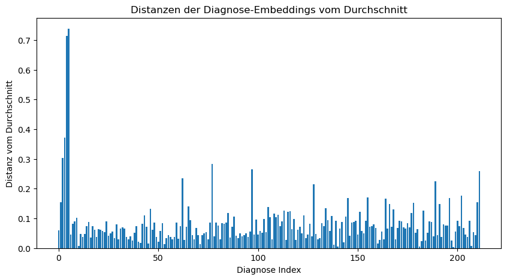

```python
# Analyse der Diagnosen-Embeddings
diagnoses_embedding_avg = np.mean(diagnoses_embedding, axis=0)
distances_diagnoses = np.linalg.norm(diagnoses_embedding - diagnoses_embedding_avg, axis=1)

# Index der am weitesten entfernten Diagnose
most_distant_diagnosis_idx = np.argmax(distances_diagnoses)

# Mapping des Indexes zur Diagnose
most_distant_diagnosis = index_to_diagnosis.get(most_distant_diagnosis_idx + 1, "Unknown")

# Ausgabe der Diagnose
print(f"Die auffälligste Diagnose ist: {most_distant_diagnosis}")

# Plotten der Distanzen für die Diagnosen
plt.figure(figsize=(10, 5))
plt.bar(range(len(distances_diagnoses)), distances_diagnoses)
plt.xlabel('Diagnose Index')
plt.ylabel('Distanz vom Durchschnitt')
plt.title('Distanzen der Diagnose-Embeddings vom Durchschnitt')
plt.show()
```

Kommentar: Man erkennt, dass die meisten Diagnosen ungefähr gleich stark vom Durchschnitt abweichen und sich um diesen streuen. Es gibt einige Ausreißer, wobei die Ausreißer zu Beginn des Diagnoseindexes besonders hoch sind. Hier ist die auffälligste Diagnose die Diagnose R07 (Hals- und Brustschmerzen). Für fehlende Diagnosen wird ein Null-Token und eine Null-Diagnose ('Unknown') genutzt.

```
Das auffälligste Alter ist: 44
```

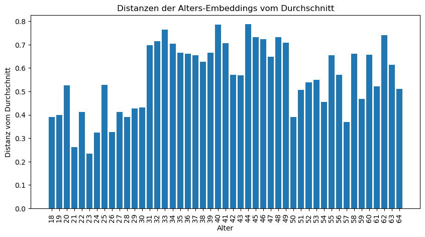

```python
# Analyse der Alters-Embeddings
age_embedding_avg = np.mean(age_embedding, axis=0)
distances_age = np.linalg.norm(age_embedding - age_embedding_avg, axis=1)

# Index des am weitesten entfernten Alters
most_distant_age_idx = np.argmax(distances_age)

# Ausgabe des Alters
print(f"Das auffälligste Alter ist: {most_distant_age_idx + min(dfdiagnoses_encoded['Alter'])}")

# Plotten der Distanzen für das Alter
plt.figure(figsize=(10, 5))
plt.bar(range(len(distances_age)), distances_age)
plt.xlabel('Alter')
plt.ylabel('Distanz vom Durchschnitt')
plt.title('Distanzen der Alters-Embeddings vom Durchschnitt')

# Zurückschieben der Altersranges
age_labels = [str(i + min(dfdiagnoses_encoded['Alter'])) for i in range(len(distances_age))]
plt.xticks(range(len(distances_age)), age_labels, rotation='vertical')

# Plotten
plt.show()
```

```
Altersgruppen-Embeddings Mittelwerte:
Age Range 1 (18-30): [0.4713829  0.42156485]
Age Range 2 (31-50): [-0.27859977 -0.2687512 ]
Age Range 3 (51-64): [0.51628405 0.6161608 ]
```

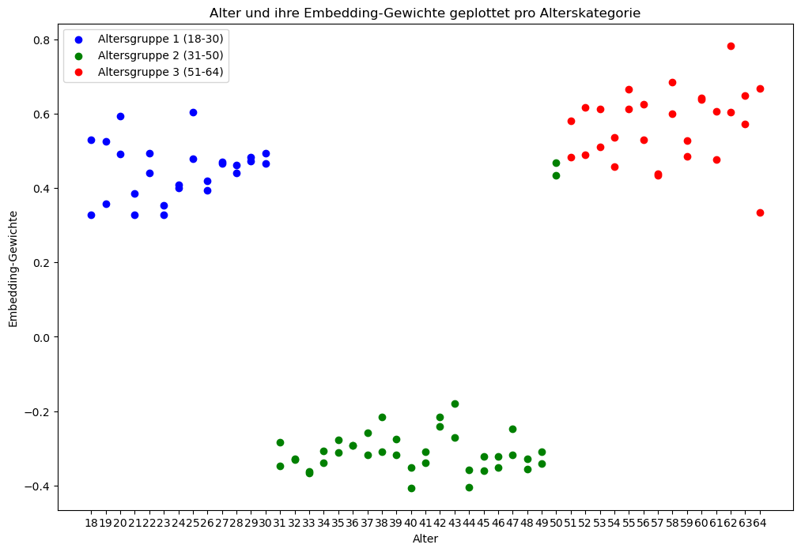

```python
# Alters-Embeddings nach den Altersklassen aus Aufgabe 1 analysieren
age_ranges = [(18- min(dfdiagnoses_encoded['Alter']), 30- min(dfdiagnoses_encoded['Alter'])),\
              (31- min(dfdiagnoses_encoded['Alter']), 50- min(dfdiagnoses_encoded['Alter'])),\
              (51- min(dfdiagnoses_encoded['Alter']), 64- min(dfdiagnoses_encoded['Alter']))]

# Altersgruppen initialisieren
age_range_embeddings = {}

# Altersgruppen mit Embedding-Gewichten belegen
for i, (start, end) in enumerate(age_ranges):
    #Verschieben der Ranges, da am Anfang das Alter runtergeschoben wurde
    shifted_start = start + min(dfdiagnoses_encoded['Alter'])
    shifted_end = end + min(dfdiagnoses_encoded['Alter'])
    age_range_embeddings[f"Age Range {i+1} ({shifted_start}-{shifted_end})"] = np.mean(age_embedding[start:end+1], axis=0)

# Ausgabe der Analysen
print("Altersgruppen-Embeddings Mittelwerte:")
for age_range, embedding in age_range_embeddings.items():
    print(f"{age_range}: {embedding}")

# Farben des Plots festlegen
colors = ['blue', 'green', 'red']

# Plotten der Altersgruppen und ihrer Gewichte
plt.figure(figsize=(12,8))
for i, (start, end) in enumerate(age_ranges):
    for age in range(start, end + 1):
        shifted_start = start + min(dfdiagnoses_encoded['Alter'])
        shifted_end = end + min(dfdiagnoses_encoded['Alter'])
        plt.scatter([age] * len(age_embedding[age]), age_embedding[age], color=colors[i],\
                    label=f"Altersgruppe {i+1} ({shifted_start}-{shifted_end})" if age == start else "")

# Plotten
plt.xlabel('Alter')
plt.ylabel('Embedding-Gewichte')
plt.title('Alter und ihre Embedding-Gewichte geplottet pro Alterskategorie')
plt.legend()

# Zurückschieben der Altersranges
age_labels = [str(i + min(dfdiagnoses_encoded['Alter'])) for i in range(len(distances_age))]
plt.xticks(range(len(distances_age)), age_labels, rotation='horizontal')

# Plotten
plt.show()
```

Kommentar: Man erkennt sehr gut, dass die Altersgruppen sehr gut eingeteilt sind. Lediglich zum Alter 50 würden zwei Embeddings eher in die 3. Altersgruppe passen. Die optimalen Altergruppen wären also: 18-30, 31-49, 50-64. Die grüne Altersgruppe (Altersgruppe 2) hat negative Gewichte, was auf eine andere Behandlung als die beiden anderen Altersgruppen hinweist. Die anderen beiden Gruppen (1 und 3) zeigen eine deutliche Verschiebung in den Gewichten, was darauf hinweist, dass sie eine signifikante Rolle spielen.

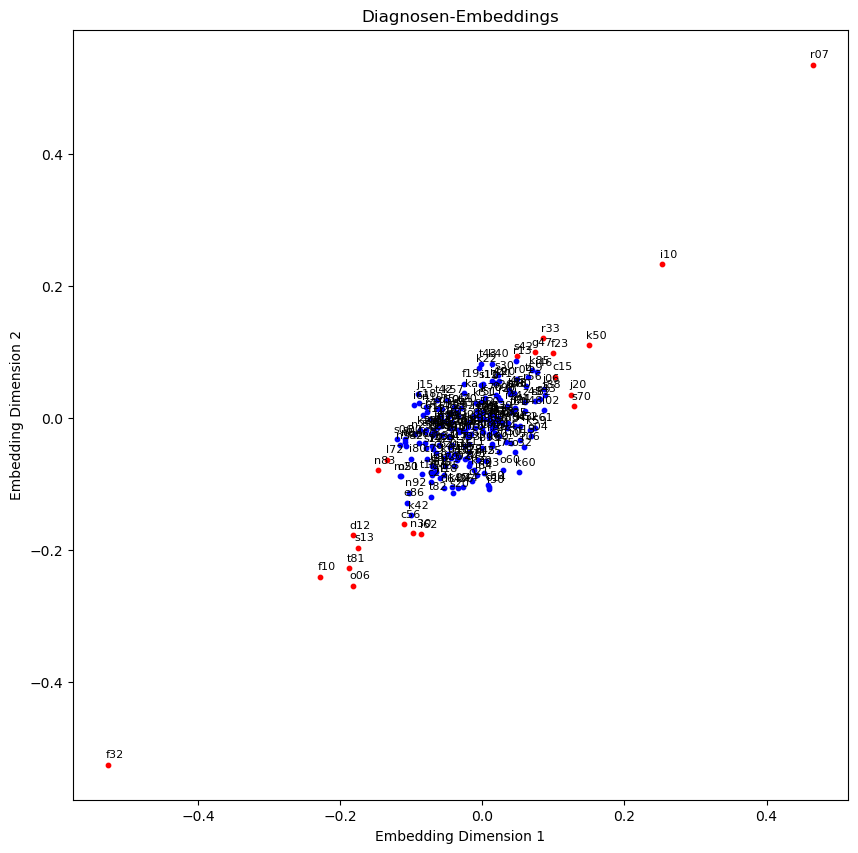

```python
# Plotten der Diagnosegewichte
# Identifizieren der Ausreißer durch IsolationForest
clf = IsolationForest(contamination=0.1)
outliers = clf.fit_predict(diagnoses_embedding)

# Scatterplot
fig, ax = plt.subplots(figsize=(10, 10))

# Mapping der Diagnosen zu ihren Gewichten
for i, embedding in enumerate(diagnoses_embedding):
    diagnosis = index_to_diagnosis.get(i + 1, "Unknown")

    # Unknown nicht plotten
    if diagnosis != "Unknown":
        color = 'red' if outliers[i] == -1 else 'blue'
        ax.scatter(embedding[0], embedding[1], color=color, s=10, label=diagnosis if outliers[i] == -1 else "")
        ax.annotate(diagnosis, (embedding[0], embedding[1]), textcoords="offset points", xytext=(5,5), ha='center', fontsize=8)

ax.set_xlabel('Embedding Dimension 1')
ax.set_ylabel('Embedding Dimension 2')
ax.set_title('Diagnosen-Embeddings')

# Plotten
plt.show()
```

Kommentar: Die rot markierten Datenpunkte markieren Ausreißer. Hier erkennt man auch gut die auffälligste Diagnose R07 (rechts oben), die wir vorher auch herausgestellt hatten. Auch sehen wir hier die deutliche Clusterung der meisten Diagnosen um den Ursprung (alle blauen Datenpunkte).